# Translation of SAS codes from Logistic Regression using SAS into R

Maciej Beręsewicz

22 June 2016

## Load packages

Data processing and visualisation

```r
library(haven)
library(ggplot2)
library(dplyr)
library(broom)
library(sjPlot)
library(tidyr)
```

Packages that will be useful for logistic regression in R

```r
library(nlme) ## mixed models with more advanced covariance structures
library(lme4) ## mixed models for glm
library(mlogit) ## multinomial (mixed) logistic regression
library(mnlogit)  ## multinomial (mixed) logistic regression
library(MASS) ## ordinal logistic regression
library(rms) ## package that contain measures of fit for logistic regression
library(BaylorEdPsych) ## package that contain measures of fit for logistic regression
library(sandwich) ## robust ovariance matrix estimators
library(lmtest) ## testing assumptions
library(mfx) ## Marginal Effects, Odds Ratios and Incidence Rate Ratios for GLMs
library(Hmisc) ## useful functions for rms package
library(lsmeans) # install this package to estimate means
library(gmodels) # sas-like contrasts
library(elrm) # exact logisit regression
library(logistf) # for firth penalized likelihood
#library(plsc) ## package ‘plsc’ is not available (for R version 3.3.0)
library(ResourceSelection) ## for hosmer lemenshof statistic
library(pROC)
library(ROCR)
library(sjPlot) ## nice tables
library(survey) ## for analysing survey data
library(geepack) ## for proc genmod (generalized estimation equations)
library(gee) ## for proc genmod (generalized estimation equations)
library(geeM) # for gee models with Matrix based implementation
library(multgee) ## multinomial and ordinal
library(repolr) ## logistic regression
library(MuMIn) ## to tools for comparing models
library(Zelig) ## different   models
library(glmmML) ## Generalized Linear Models with random intercept (Generalized linear models with clustering)
library(survival) ## for conditional logistic regression
library(varComp) ## test variance components
```

## Load data

```r
files <- list.files(pattern = '*.sas7bdat')
base_names <- gsub('\\.sas7bdat','',files)
sas_datasets <- lapply(files,read_sas)
names(sas_datasets) <- base_names
str(sas_datasets,1)
```

```
## List of 15
##  $ afqt    :Classes 'tbl_df', 'tbl' and 'data.frame':    48 obs. of  5 variables:
##  $ afterlif:Classes 'tbl_df', 'tbl' and 'data.frame':    12 obs. of  4 variables:
##  $ casecont:Classes 'tbl_df', 'tbl' and 'data.frame':    1582 obs. of  8 variables:
##  $ chocs   :Classes 'tbl_df', 'tbl' and 'data.frame':    80 obs. of  5 variables:
##  $ happy   :Classes 'tbl_df', 'tbl' and 'data.frame':    18 obs. of  4 variables:
##  $ mobility:Classes 'tbl_df', 'tbl' and 'data.frame':    25 obs. of  3 variables:
##  $ nihdoc  :Classes 'tbl_df', 'tbl' and 'data.frame':    40 obs. of  3 variables:
##  $ penalty :Classes 'tbl_df', 'tbl' and 'data.frame':    147 obs. of  6 variables:
##  $ postdoc :Classes 'tbl_df', 'tbl' and 'data.frame':    554 obs. of  9 variables:
##  $ prognosi:Classes 'tbl_df', 'tbl' and 'data.frame':    125 obs. of  8 variables:
##  $ promo   :Classes 'tbl_df', 'tbl' and 'data.frame':    2797 obs. of  6 variables:
##  $ ptsd    :Classes 'tbl_df', 'tbl' and 'data.frame':    948 obs. of  7 variables:
##  $ travel  :Classes 'tbl_df', 'tbl' and 'data.frame':    840 obs. of  8 variables:
##  $ wallet  :Classes 'tbl_df', 'tbl' and 'data.frame':    195 obs. of  5 variables:
##  $ wisc    :Classes 'tbl_df', 'tbl' and 'data.frame':    32 obs. of  5 variables:
```

## Chapter 2: Binary Logistic Regression with PROC LOGISTIC: basics

### Output 2.1 – linear regression

SAS Code:

```
/* The following program is found on page 9 */
PROC REG DATA=penalty;
  MODEL death=blackd whitvic serious;
RUN;
```

R Code:

```r
output2.1 <- lm(formula = death ~ blackd + whitvic + serious,
                data = sas_datasets[['penalty']])
summary(output2.1)
```

```
##
## Call:
## lm(formula = death ~ blackd + whitvic + serious, data = sas_datasets[["penalty"]])
##
## Residuals:
##     Min      1Q  Median      3Q     Max
## -0.6452 -0.3666 -0.2019  0.5067  0.9704
##
## Coefficients:
##             Estimate Std. Error t value Pr(>|t|)
## (Intercept) -0.05492    0.12499  -0.439  0.66102
## blackd       0.12197    0.08224   1.483  0.14026
## whitvic      0.05331    0.08411   0.634  0.52724
## serious      0.03840    0.01200   3.200  0.00169 **
## ---
## Signif. codes:  0 '***' 0.001 '**' 0.01 '*' 0.05 '.' 0.1 ' ' 1
##
## Residual standard error: 0.4609 on 143 degrees of freedom
## Multiple R-squared:  0.07929,    Adjusted R-squared:  0.05998
## F-statistic: 4.105 on 3 and 143 DF,  p-value: 0.007899
```

### Output 2.2 – robust standard errors

SAS Code:

```
/* The following program is found on page 13 */
PROC REG DATA=penalty;
  MODEL death=blackd whitvic serious / HCC;
RUN;
```

R Code:

Step by step

```r
output2.1 %>%
  vcovHC(type = 'HC') %>%
  diag() %>%
  sqrt()
```

```
## (Intercept)      blackd     whitvic     serious
##  0.11959473  0.08197362  0.08314526  0.01140468
```

using `lmtest` package

```r
coeftest(x = output2.1, vcov. = sandwich)
```

```
##
## t test of coefficients:
##
##              Estimate Std. Error t value  Pr(>|t|)
## (Intercept) -0.054924   0.119595 -0.4592 0.6467537
## blackd       0.121974   0.081974  1.4880 0.1389622
## whitvic      0.053309   0.083145  0.6412 0.5224481
## serious      0.038403   0.011405  3.3673 0.0009753 ***
## ---
## Signif. codes:  0 '***' 0.001 '**' 0.01 '*' 0.05 '.' 0.1 ' ' 1
```

```r
coeftest(x = output2.1, vcov = vcovHC(output2.1, type = 'HC'))
```

```
##
## t test of coefficients:
##
##              Estimate Std. Error t value  Pr(>|t|)
## (Intercept) -0.054924   0.119595 -0.4592 0.6467537
## blackd       0.121974   0.081974  1.4880 0.1389622
## whitvic      0.053309   0.083145  0.6412 0.5224481
## serious      0.038403   0.011405  3.3673 0.0009753 ***
## ---
## Signif. codes:  0 '***' 0.001 '**' 0.01 '*' 0.05 '.' 0.1 ' ' 1
```

using `rms` package

```r
output2.1_lm <- ols(
  formula = death ~ blackd + whitvic + serious,
  data = sas_datasets[['penalty']],
  x = TRUE
  )
  robcov(output2.1_lm)
```

```
##
## Linear Regression Model
##
## ols(formula = death ~ blackd + whitvic + serious, data = sas_datasets[["penalty"]],
##     x = TRUE)
##                  Model Likelihood    Discrimination
##                        Ratio Test           Indexes
## Obs      147    LR chi2     12.14    R2       0.079
## sigma 0.4609    d.f.            3    R2 adj   0.060
## d.f.     143    Pr(> chi2) 0.0069    g        0.153
##
## Residuals
##
##     Min      1Q  Median      3Q     Max
## -0.6452 -0.3666 -0.2019  0.5067  0.9704
##
##           Coef    S.E.   t     Pr(>|t|)
## Intercept -0.0549 0.1196 -0.46 0.6468
## blackd     0.1220 0.0820  1.49 0.1390
## whitvic    0.0533 0.0831  0.64 0.5224
## serious    0.0384 0.0114  3.37 0.0010
```

### Output 2.3 – intro to logistic regression

SAS code:

```
PROC LOGISTIC DATA=penalty;
  MODEL death(EVENT='1')=blackd whitvic serious;
RUN;
```

```r
output2.3 <- glm(
  formula = death ~ blackd + whitvic + serious,
  data = sas_datasets[['penalty']],
  family = binomial(link = 'logit')
)
summary(output2.3)
```

```
##
## Call:
## glm(formula = death ~ blackd + whitvic + serious, family = binomial(link = "logit"),
##     data = sas_datasets[["penalty"]])
##
## Deviance Residuals:
##     Min       1Q   Median       3Q      Max
## -1.5108  -0.9360  -0.6628   1.1706   2.1639
##
## Coefficients:
##             Estimate Std. Error z value Pr(>|z|)
## (Intercept) -2.65165    0.67477  -3.930 8.51e-05 ***
## blackd       0.59518    0.39394   1.511  0.13083
## whitvic      0.25647    0.40019   0.641  0.52161
## serious      0.18705    0.06122   3.055  0.00225 **
## ---
## Signif. codes:  0 '***' 0.001 '**' 0.01 '*' 0.05 '.' 0.1 ' ' 1
##
## (Dispersion parameter for binomial family taken to be 1)
##
##     Null deviance: 188.49  on 146  degrees of freedom
## Residual deviance: 176.28  on 143  degrees of freedom
## AIC: 184.28
##
## Number of Fisher Scoring iterations: 4
```

```r
### Odds ratio estimates
output2.3 %>%
  coef() %>%
  exp()
```

```
## (Intercept)      blackd     whitvic     serious
##  0.07053482  1.81336619  1.29236264  1.20568950
```

```r
output2.3 %>%
  confint() %>%
  exp()
```

```
##                  2.5 %    97.5 %
## (Intercept) 0.01735762 0.2484335
## blackd      0.84414270 3.9819199
## whitvic     0.59315310 2.8686069
## serious     1.07334774 1.3662986
```

The same but using `rms` package

```r
output2.3_rms <- lrm(
  formula = death ~ blackd + whitvic + serious,
  data = sas_datasets[['penalty']]
)
coef(output2.3_rms)
```

```
##  Intercept     blackd    whitvic    serious
## -2.6516488  0.5951849  0.2564720  0.1870516
```

### Output 2.4 – Marginal Effects

```
/* The following program is found on page 29 */
PROC QLIM DATA=penalty;
  ENDOGENOUS death~DISCRETE(DIST=LOGISTIC);
  MODEL death = blackd whitvic serious;
  OUTPUT OUT=a MARGINAL;
PROC PRINT DATA=a(OBS=10);
  VAR meff_p2_blackd meff_p2_whitvic meff_p2_serious;
RUN;
```

```r
output2.4 <- logitmfx(
  formula = death ~ blackd + whitvic + serious,
  data = sas_datasets[['penalty']]
)
output2.4
```

```
## Call:
## logitmfx(formula = death ~ blackd + whitvic + serious, data = sas_datasets[["penalty"]])
##
## Marginal Effects:
##            dF/dx Std. Err.      z    P>|z|
## blackd  0.130145  0.085023 1.5307 0.125845
## whitvic 0.055755  0.086018 0.6482 0.516868
## serious 0.041065  0.013180 3.1158 0.001835 **
## ---
## Signif. codes:  0 '***' 0.001 '**' 0.01 '*' 0.05 '.' 0.1 ' ' 1
##
## dF/dx is for discrete change for the following variables:
##
## [1] "blackd"  "whitvic"
```

```r
## default marginal effects represent the partial effects for the average observation. If atmean = FALSE the function calculates average partial effects.

output2.4 <- logitmfx(
  formula = death ~ blackd + whitvic + serious,
  data = sas_datasets[['penalty']],
  atmean = FALSE
)
output2.4
```

```
## Call:
## logitmfx(formula = death ~ blackd + whitvic + serious, data = sas_datasets[["penalty"]],
##     atmean = FALSE)
##
## Marginal Effects:
##            dF/dx Std. Err.      z    P>|z|
## blackd  0.122857  0.079603 1.5434 0.122743
## whitvic 0.052551  0.081082 0.6481 0.516908
## serious 0.038605  0.014420 2.6771 0.007426 **
## ---
## Signif. codes:  0 '***' 0.001 '**' 0.01 '*' 0.05 '.' 0.1 ' ' 1
##
## dF/dx is for discrete change for the following variables:
##
## [1] "blackd"  "whitvic"
```

### Output 2.5 – Using class variable

```
/* The following program is found on page 30 */
PROC LOGISTIC DATA=penalty;
  CLASS culp /PARAM=REF;
  MODEL death(EVENT='1') = blackd whitvic culp ;
RUN;
```

```r
output2.5 <- glm(
  formula = death ~ blackd + whitvic + factor(culp),
  data = sas_datasets[['penalty']],
  family = binomial()
)
summary(output2.5)
```

```
##
## Call:
## glm(formula = death ~ blackd + whitvic + factor(culp), family = binomial(),
##     data = sas_datasets[["penalty"]])
##
## Deviance Residuals:
##     Min       1Q   Median       3Q      Max
## -2.1797  -0.5659  -0.2469   0.5239   2.3072
##
## Coefficients:
##               Estimate Std. Error z value Pr(>|z|)
## (Intercept)    -4.3137     0.8873  -4.861 1.17e-06 ***
## blackd          1.7246     0.6130   2.813   0.0049 **
## whitvic         0.8385     0.5694   1.473   0.1408
## factor(culp)2   1.8123     0.7105   2.551   0.0107 *
## factor(culp)3   3.3376     0.7930   4.209 2.57e-05 ***
## factor(culp)4   4.5060     0.9086   4.959 7.08e-07 ***
## factor(culp)5   4.8670     0.8251   5.899 3.66e-09 ***
## ---
## Signif. codes:  0 '***' 0.001 '**' 0.01 '*' 0.05 '.' 0.1 ' ' 1
##
## (Dispersion parameter for binomial family taken to be 1)
##
##     Null deviance: 188.49  on 146  degrees of freedom
## Residual deviance: 108.22  on 140  degrees of freedom
## AIC: 122.22
##
## Number of Fisher Scoring iterations: 5
```

```r
### factor

sas_datasets[['penalty']]$culp <- factor(sas_datasets[['penalty']]$culp)

output2.5 <- glm(
  formula = death ~ blackd + whitvic + relevel(culp,ref='5'),
  data = sas_datasets[['penalty']],
  family = binomial()
)
summary(output2.5)
```

```
##
## Call:
## glm(formula = death ~ blackd + whitvic + relevel(culp, ref = "5"),
##     family = binomial(), data = sas_datasets[["penalty"]])
##
## Deviance Residuals:
##     Min       1Q   Median       3Q      Max
## -2.1797  -0.5659  -0.2469   0.5239   2.3072
##
## Coefficients:
##                           Estimate Std. Error z value Pr(>|z|)
## (Intercept)                 0.5533     0.7030   0.787   0.4313
## blackd                      1.7246     0.6130   2.813   0.0049 **
## whitvic                     0.8385     0.5694   1.473   0.1408
## relevel(culp, ref = "5")1  -4.8670     0.8251  -5.899 3.66e-09 ***
## relevel(culp, ref = "5")2  -3.0547     0.7754  -3.939 8.17e-05 ***
## relevel(culp, ref = "5")3  -1.5294     0.8399  -1.821   0.0686 .
## relevel(culp, ref = "5")4  -0.3610     0.8857  -0.408   0.6835
## ---
## Signif. codes:  0 '***' 0.001 '**' 0.01 '*' 0.05 '.' 0.1 ' ' 1
##
## (Dispersion parameter for binomial family taken to be 1)
##
##     Null deviance: 188.49  on 146  degrees of freedom
## Residual deviance: 108.22  on 140  degrees of freedom
## AIC: 122.22
##
## Number of Fisher Scoring iterations: 5
```

Now do the same in `rms` package

```r
output2.5_rms <- lrm(
  formula = death ~ blackd + whitvic + culp,
  data = sas_datasets[['penalty']]
)
output2.5_rms
```

```
##
## Logistic Regression Model
##
## lrm(formula = death ~ blackd + whitvic + culp, data = sas_datasets[["penalty"]])
##                        Model Likelihood    Discrimination    Rank Discrim.
##                              Ratio Test           Indexes          Indexes
## Obs           147    LR chi2      80.27    R2       0.582    C       0.900
##  0             97    d.f.             6    g        2.353    Dxy     0.800
##  1             50    Pr(> chi2) <0.0001    gr      10.517    gamma   0.828
## max |deriv| 3e-07                          gp       0.361    tau-a   0.362
##                                            Brier    0.115
##
##           Coef    S.E.   Wald Z Pr(>|Z|)
## Intercept -4.3137 0.8874 -4.86  <0.0001
## blackd     1.7246 0.6131  2.81  0.0049
## whitvic    0.8385 0.5694  1.47  0.1408
## culp=2     1.8123 0.7105  2.55  0.0107
## culp=3     3.3376 0.7930  4.21  <0.0001
## culp=4     4.5060 0.9086  4.96  <0.0001
## culp=5     4.8670 0.8251  5.90  <0.0001
```

```r
sas_datasets[['penalty']]$culp <-
  relevel(sas_datasets[['penalty']]$culp,ref='5')

output2.5_rms <- lrm(
  formula = death ~ blackd + whitvic + culp,
  data = sas_datasets[['penalty']]
)

output2.5_rms
```

```
##
## Logistic Regression Model
##
## lrm(formula = death ~ blackd + whitvic + culp, data = sas_datasets[["penalty"]])
##                        Model Likelihood    Discrimination    Rank Discrim.
##                              Ratio Test           Indexes          Indexes
## Obs           147    LR chi2      80.27    R2       0.582    C       0.900
##  0             97    d.f.             6    g        2.353    Dxy     0.800
##  1             50    Pr(> chi2) <0.0001    gr      10.517    gamma   0.828
## max |deriv| 3e-07                          gp       0.361    tau-a   0.362
##                                            Brier    0.115
##
##           Coef    S.E.   Wald Z Pr(>|Z|)
## Intercept  0.5533 0.7031  0.79  0.4313
## blackd     1.7246 0.6131  2.81  0.0049
## whitvic    0.8385 0.5694  1.47  0.1408
## culp=1    -4.8670 0.8251 -5.90  <0.0001
## culp=2    -3.0547 0.7754 -3.94  <0.0001
## culp=3    -1.5294 0.8400 -1.82  0.0686
## culp=4    -0.3610 0.8857 -0.41  0.6835
```

```r
anova(output2.5_rms)
```

```
##                 Wald Statistics          Response: death
##
##  Factor     Chi-Square d.f. P
##  blackd      7.91      1    0.0049
##  whitvic     2.17      1    0.1408
##  culp       44.01      4    <.0001
##  TOTAL      44.33      6    <.0001
```

### Output 2.6 – results from Test and Contrast Statements

```
/* The following program is found on page 30 */
PROC LOGISTIC DATA=penalty;
  CLASS culp /PARAM=REF;
  MODEL death(EVENT='1') = blackd whitvic culp ;
  CONTRAST 'culp2 vs. culp3' clup 0 1 -1 0 ;
  TEST culp2 = culp3;
RUN;
```

The same using `contrast` function from `rms` package

**WHY DATADIST**

```r
## Distribution Summaries for Predictor Variables
d <- datadist(sas_datasets[['penalty']])

## why??
options(datadist = 'd')

## defining contrasts
rms::contrast(output2.5_rms,
         list(culp = 2),
         list(culp = 3))
```

```
##   blackd whitvic  Contrast      S.E.     Lower       Upper     Z Pr(>|z|)
## 1      0       0 -1.525338 0.7809214 -3.055916 0.005239369 -1.95   0.0508
##
## Confidence intervals are 0.95 individual intervals
```

```r
## all vs 5
rms::contrast(output2.5_rms,
         list(culp = 1:4),
         list(culp = 5))
```

```
##   blackd whitvic   Contrast      S.E.     Lower      Upper     Z Pr(>|z|)
## 1      0       0 -4.8670053 0.8251226 -6.484216 -3.2497947 -5.90   0.0000
## 2      0       0 -3.0547207 0.7754364 -4.574548 -1.5348933 -3.94   0.0001
## 3      0       0 -1.5293823 0.8399540 -3.175662  0.1168972 -1.82   0.0686
## 4      0       0 -0.3610461 0.8856725 -2.096932  1.3748401 -0.41   0.6835
##
## Confidence intervals are 0.95 individual intervals
```

```r
## all vs 5 - test
rms::contrast(output2.5_rms,
         list(culp = 1:4),
         list(culp = 5),
         typ = 'joint')
```

```
##   blackd whitvic   Contrast      S.E.     Lower      Upper     Z Pr(>|z|)
## 1      0       0 -4.8670053 0.8251226 -6.484216 -3.2497947 -5.90   0.0000
## 2      0       0 -3.0547207 0.7754364 -4.574548 -1.5348933 -3.94   0.0001
## 3      0       0 -1.5293823 0.8399540 -3.175662  0.1168972 -1.82   0.0686
## 4      0       0 -0.3610461 0.8856725 -2.096932  1.3748401 -0.41   0.6835
##
## Joint test for all contrasts=0:
##
## Chi-square=44.01 with 4 d.f.  P=0
##
## Confidence intervals are 0.95 individual intervals
```

### Output 2.7 - change in contrasts

```r
### replicate odss ratio estimates from output 2.7
summary(output2.5_rms,culp=5)
```

```
##              Effects              Response : death
##
##  Factor      Low High Diff. Effect     S.E.    Lower 0.95 Upper 0.95
##  blackd      0   1     1     1.7246000 0.61305  0.5230700  2.926200
##   Odds Ratio 0   1     1     5.6105000      NA  1.6872000 18.657000
##  whitvic     0   1     1     0.8385400 0.56940 -0.2774700  1.954500
##   Odds Ratio 0   1     1     2.3130000      NA  0.7577000  7.060700
##  culp - 1:5  1   2    NA    -4.8670000 0.82512 -6.4842000 -3.249800
##   Odds Ratio 1   2    NA     0.0076964      NA  0.0015274  0.038782
##  culp - 2:5  1   3    NA    -3.0547000 0.77544 -4.5745000 -1.534900
##   Odds Ratio 1   3    NA     0.0471360      NA  0.0103110  0.215480
##  culp - 3:5  1   4    NA    -1.5294000 0.83995 -3.1757000  0.116900
##   Odds Ratio 1   4    NA     0.2166700      NA  0.0417660  1.124000
##  culp - 4:5  1   5    NA    -0.3610500 0.88567 -2.0969000  1.374800
##   Odds Ratio 1   5    NA     0.6969500      NA  0.1228300  3.954400
```

```r
output2.5_glm <- glm(
  formula = death ~ blackd + whitvic + culp,
  data = sas_datasets[['penalty']],
  family = binomial()
)

summary(output2.5_glm)
```

```
##
## Call:
## glm(formula = death ~ blackd + whitvic + culp, family = binomial(),
##     data = sas_datasets[["penalty"]])
##
## Deviance Residuals:
##     Min       1Q   Median       3Q      Max
## -2.1797  -0.5659  -0.2469   0.5239   2.3072
##
## Coefficients:
##             Estimate Std. Error z value Pr(>|z|)
## (Intercept)   0.5533     0.7030   0.787   0.4313
## blackd        1.7246     0.6130   2.813   0.0049 **
## whitvic       0.8385     0.5694   1.473   0.1408
## culp1        -4.8670     0.8251  -5.899 3.66e-09 ***
## culp2        -3.0547     0.7754  -3.939 8.17e-05 ***
## culp3        -1.5294     0.8399  -1.821   0.0686 .
## culp4        -0.3610     0.8857  -0.408   0.6835
## ---
## Signif. codes:  0 '***' 0.001 '**' 0.01 '*' 0.05 '.' 0.1 ' ' 1
##
## (Dispersion parameter for binomial family taken to be 1)
##
##     Null deviance: 188.49  on 146  degrees of freedom
## Residual deviance: 108.22  on 140  degrees of freedom
## AIC: 122.22
##
## Number of Fisher Scoring iterations: 5
```

```r
lsmeans(object = output2.5_glm,
        specs = 'culp') %>%
  contrast()
```

```
##  contrast   estimate        SE df z.ratio p.value
##  5 effect  1.9624309 0.5263765 NA   3.728  0.0005
##  1 effect -2.9045745 0.5006756 NA  -5.801  <.0001
##  2 effect -1.0922898 0.4644688 NA  -2.352  0.0234
##  3 effect  0.4330486 0.5292169 NA   0.818  0.4132
##  4 effect  1.6013848 0.6025801 NA   2.658  0.0131
##
## P value adjustment: fdr method for 5 tests
```

```r
lsmeans(object = output2.5_glm,
        specs = 'culp') %>%
  pairs()
```

```
##  contrast   estimate        SE df z.ratio p.value
##  5 - 1     4.8670054 0.8251053 NA   5.899  <.0001
##  5 - 2     3.0547208 0.7754292 NA   3.939  0.0008
##  5 - 3     1.5293823 0.8399495 NA   1.821  0.3614
##  5 - 4     0.3610461 0.8856691 NA   0.408  0.9942
##  1 - 2    -1.8122846 0.7104719 NA  -2.551  0.0798
##  1 - 3    -3.3376231 0.7930265 NA  -4.209  0.0002
##  1 - 4    -4.5059593 0.9086104 NA  -4.959  <.0001
##  2 - 3    -1.5253384 0.7809173 NA  -1.953  0.2892
##  2 - 4    -2.6936746 0.8656886 NA  -3.112  0.0160
##  3 - 4    -1.1683362 0.9180236 NA  -1.273  0.7081
##
## Results are given on the log (not the response) scale.
## P value adjustment: tukey method for comparing a family of 5 estimates
## Tests are performed on the log scale
```

### Output 2.9 - multiplicative variables

```
/* The following program is found on page 36 */
PROC LOGISTIC DATA=penalty;
  MODEL death(EVENT='1') = blackd whitvic culp blackd*whitvic;
RUN;
```

```r
sas_datasets[['penalty']]$culp <- as.numeric(sas_datasets[['penalty']]$culp)

output2.9 <- glm(
  formula = death ~ blackd*whitvic + culp,
  data = sas_datasets[['penalty']],
  family = binomial()
)

summary(output2.9)
```

```
##
## Call:
## glm(formula = death ~ blackd * whitvic + culp, family = binomial(),
##     data = sas_datasets[["penalty"]])
##
## Deviance Residuals:
##     Min       1Q   Median       3Q      Max
## -1.1566  -0.9343  -0.8394   1.2755   1.9637
##
## Coefficients:
##                Estimate Std. Error z value Pr(>|z|)
## (Intercept)     -1.9823     0.7496  -2.644  0.00818 **
## blackd           0.9564     0.7172   1.333  0.18238
## whitvic          0.6973     0.7029   0.992  0.32118
## culp             0.2115     0.1540   1.373  0.16964
## blackd:whitvic  -0.5665     0.8579  -0.660  0.50909
## ---
## Signif. codes:  0 '***' 0.001 '**' 0.01 '*' 0.05 '.' 0.1 ' ' 1
##
## (Dispersion parameter for binomial family taken to be 1)
##
##     Null deviance: 188.49  on 146  degrees of freedom
## Residual deviance: 184.07  on 142  degrees of freedom
## AIC: 194.07
##
## Number of Fisher Scoring iterations: 4
```

```r
output2.9_rms <- lrm(
  formula = death ~ blackd*whitvic + culp,
  data = sas_datasets[['penalty']]
)
output2.9_rms
```

```
##
## Logistic Regression Model
##
## lrm(formula = death ~ blackd * whitvic + culp, data = sas_datasets[["penalty"]])
##                       Model Likelihood    Discrimination    Rank Discrim.
##                             Ratio Test           Indexes          Indexes
## Obs           147    LR chi2      4.43    R2       0.041    C       0.612
##  0             97    d.f.            4    g        0.424    Dxy     0.225
##  1             50    Pr(> chi2) 0.3515    gr       1.528    gamma   0.233
## max |deriv| 1e-10                         gp       0.090    tau-a   0.102
##                                           Brier    0.216
##
##                  Coef    S.E.   Wald Z Pr(>|Z|)
## Intercept        -1.9823 0.7496 -2.64  0.0082
## blackd            0.9564 0.7172  1.33  0.1824
## whitvic           0.6973 0.7029  0.99  0.3212
## culp              0.2115 0.1540  1.37  0.1696
## blackd * whitvic -0.5665 0.8579 -0.66  0.5091
```

## Chapter 3

### Output 3.8 – confidence intervals

**Profile-likelihood confidence intervals**

```
/* The following program is found on page 54 */
PROC LOGISTIC DATA=penalty;
  WHERE blackd=0;
  CLASS culp /PARAM=REF;
  MODEL death(EVENT='1') = culp serious / CLPARM=PL ALPHA=.01;
RUN;
```

```r
sas_datasets[['penalty']]$culp <- factor(sas_datasets[['penalty']]$culp)
output3.8 <- glm(
  formula  = death ~ culp + serious,
  data = subset(sas_datasets[['penalty']], blackd == 0),
  family = binomial())

confint(output3.8) %>%
  exp()
```

```
##                   2.5 %       97.5 %
## (Intercept) 0.956395977 1.082985e+03
## culp2                NA 8.620248e+38
## culp3       0.001312386 1.814897e-01
## culp4       0.047857021 4.823398e+00
## culp5       0.042744938 3.047884e+00
## serious     0.627273466 1.094811e+00
```

### Output 3.9 – exact regression

```
/* The following program is found on page 55 */
PROC LOGISTIC DATA=penalty;
  WHERE blackd=0;
  CLASS culp /PARAM=REF;
  MODEL death(EVENT='1') = culp serious;
  EXACT culp serious / ESTIMATE=BOTH;
RUN;
```

With package `elrm`

```r
### data need to be in an aggregated form

for_exact <- sas_datasets[['penalty']] %>%
  group_by(death,blackd,culp) %>%
  summarise(n=n()) %>%
  spread(death,n,fill=0,sep='_')  %>%
  ungroup() %>%
  mutate(n = death_0+death_1,
         l = 1) %>%
  filter(blackd == 1)  %>%
  spread(culp,l,fill=0,sep='_')

output_3.9 <- elrm(
  formula = death_1/n ~ culp_1 + culp_2 + culp_3 + culp_4,
  dataset = for_exact,
  interest = ~ culp_1 + culp_2 + culp_3 + culp_4,
  iter = 50000,
  burnIn = 5000
)
```

[output not shown]

```r
summary(output_3.9)
```

```
##
## Call:
## [[1]]
## elrm(formula = death_1/n ~ culp_1 + culp_2 + culp_3 + culp_4,
##     interest = ~culp_1 + culp_2 + culp_3 + culp_4, iter = 50000,
##     dataset = for_exact, burnIn = 5000)
##
##
## Results:
##        estimate p-value p-value_se mc_size
## joint        NA       0          0   45000
## culp_1       NA      NA         NA       0
## culp_2       NA      NA         NA       0
## culp_3       NA      NA         NA       0
## culp_4       NA      NA         NA       0
##
## 95% Confidence Intervals for Parameters
##
##        lower upper
## culp_1    NA    NA
## culp_2    NA    NA
## culp_3    NA    NA
## culp_4    NA    NA
```

### Output 3.10 – penalized likelihood – Firth

```
/* The following program is found on page 58 */
PROC LOGISTIC DATA=penalty;
  WHERE blackd=0;
  CLASS culp /PARAM=REF;
  MODEL death(EVENT='1') = culp serious / FIRTH
    CLPARM=PL;
RUN;
```

With package `logistf`

```r
output3.10 <- logistf(
  formula  = death ~ culp + serious,
  data = subset(sas_datasets[['penalty']], blackd == 0))
summary(output3.10)
```

```
## logistf(formula = death ~ culp + serious, data = subset(sas_datasets[["penalty"]],
##     blackd == 0))
##
## Model fitted by Penalized ML
## Confidence intervals and p-values by Profile Likelihood Profile Likelihood Profile Likelihood Profile Likelihood Profile Likelihood Profile Likelihood
##
##                   coef  se(coef)  lower 0.95 upper 0.95      Chisq
## (Intercept)  2.6718077 1.5979638  -0.2208428   6.159085  3.2498595
## culp2       -5.8881311 1.7393375 -11.0072448  -3.148053 26.8693417
## culp3       -3.3430260 1.1156164  -5.8204613  -1.415951 13.0820110
## culp4       -0.6973489 1.0963192  -2.7746672   1.396322  0.4547515
## culp5       -0.8444125 1.0209462  -2.8642836   1.062377  0.7606041
## serious     -0.1415559 0.1264627  -0.4100482   0.096433  1.3341037
##                        p
## (Intercept) 7.142958e-02
## culp2       2.176848e-07
## culp3       2.981452e-04
## culp4       5.000872e-01
## culp5       3.831395e-01
## serious     2.480765e-01
##
## Likelihood ratio test=41.37169 on 5 df, p=7.892633e-08, n=74
## Wald test = 18.29382 on 5 df, p = 0.002599836
##
## Covariance-Matrix:
##            [,1]        [,2]        [,3]        [,4]        [,5]
## [1,]  2.5534883 -1.55664300 -1.25711483 -0.72175255 -0.91862802
## [2,] -1.5566430  3.02529483  0.86484472  0.57915337  0.68421422
## [3,] -1.2571148  0.86484472  1.24459987  0.53630572  0.61377849
## [4,] -0.7217525  0.57915337  0.53630572  1.20191573  0.48788503
## [5,] -0.9186280  0.68421422  0.61377849  0.48788503  1.04233112
## [6,] -0.1848912  0.09866558  0.07275683  0.02644878  0.04347822
##             [,6]
## [1,] -0.18489124
## [2,]  0.09866558
## [3,]  0.07275683
## [4,]  0.02644878
## [5,]  0.04347822
## [6,]  0.01599282
```

### Output 3.14 – goodness of fit

```
/* The following program is found on page 66 */
PROC LOGISTIC DATA=penalty;
  MODEL death(EVENT='1') = blackd whitvic culp / LACKFIT;
RUN;
```

```r
output3.14 <- glm(
  formula = death ~ blackd + whitvic + culp,
  data = sas_datasets[['penalty']],
  family = binomial()
)

hoslem.test(x = sas_datasets[['penalty']]$death,
            y = fitted(output3.14))
```

```
##
##  Hosmer and Lemeshow goodness of fit (GOF) test
##
## data:  sas_datasets[["penalty"]]$death, fitted(output3.14)
## X-squared = NaN, df = 8, p-value = NA
```

With `rms` package

```r
output3.14_rms <- lrm(
  formula = death ~ blackd + whitvic + culp,
  data = sas_datasets[['penalty']],
  y= T, x = T
)
resid(output3.14_rms,'gof')
```

```
## Sum of squared errors     Expected value|H0                    SD
##            16.9765442            16.6341572             0.3382442
##                     Z                     P
##             1.0122480             0.3114195
```

### Output 3.15 and 3.16 – measures of quality

```
PROC LOGISTIC DATA=penalty;
  MODEL death(EVENT='1')=culp whitvic blackd;
  OUTPUT OUT=a PRED=yhat;
PROC MEANS;
 CLASS death;
 VAR yhat;
RUN;
```

```r
output3.15 <- glm(
  formula = death ~ blackd + whitvic + culp,
  data = sas_datasets[['penalty']],
  family = binomial()
)

output3.15_summary <- data.frame(y = sas_datasets[['penalty']]$death,
                      y_hat = fitted(output3.15))


output3.15_summary %>%
  group_by(y) %>%
  do(t = tidy(summary(.$y_hat))) %>%
  unnest(t)
```

```
## # A tibble: 2 x 7
##       y minimum      q1  median   mean     q3 maximum
##   <dbl>   <dbl>   <dbl>   <dbl>  <dbl>  <dbl>   <dbl>
## 1     0 0.01321 0.03003 0.06984 0.1733 0.1594  0.9070
## 2     1 0.06984 0.47810 0.76900 0.6639 0.8718  0.9576
```

```r
BaylorEdPsych::PseudoR2(output3.15)
```

```
##         McFadden     Adj.McFadden        Cox.Snell       Nagelkerke
##        0.4258409        0.3409562        0.4207581        0.5822932
## McKelvey.Zavoina           Effron            Count        Adj.Count
##        0.5651228        0.4854532        0.8299320        0.5000000
##              AIC    Corrected.AIC
##      122.2237973      123.0295527
```

```r
# plsc::pR2(output3.15)

output3.15_rms <- lrm(
  formula = death ~ blackd + whitvic + culp,
  data = sas_datasets[['penalty']]
)

output3.15_rms$stats
```

```
##          Obs    Max Deriv   Model L.R.         d.f.            P
## 1.470000e+02 2.551457e-07 8.026715e+01 6.000000e+00 3.108624e-15
##            C          Dxy        Gamma        Tau-a           R2
## 9.000000e-01 8.000000e-01 8.276451e-01 3.615693e-01 5.822932e-01
##        Brier            g           gr           gp
## 1.154867e-01 2.353026e+00 1.051735e+01 3.614054e-01
```

### Output 3.17 – ROC curves

```
/* The following program is found on page 76 */
PROC LOGISTIC DATA=penalty PLOTS(ONLY)=ROC;
  MODEL death(EVENT='1')=blackd whitvic culp ;
RUN;
```

With `pROC` package

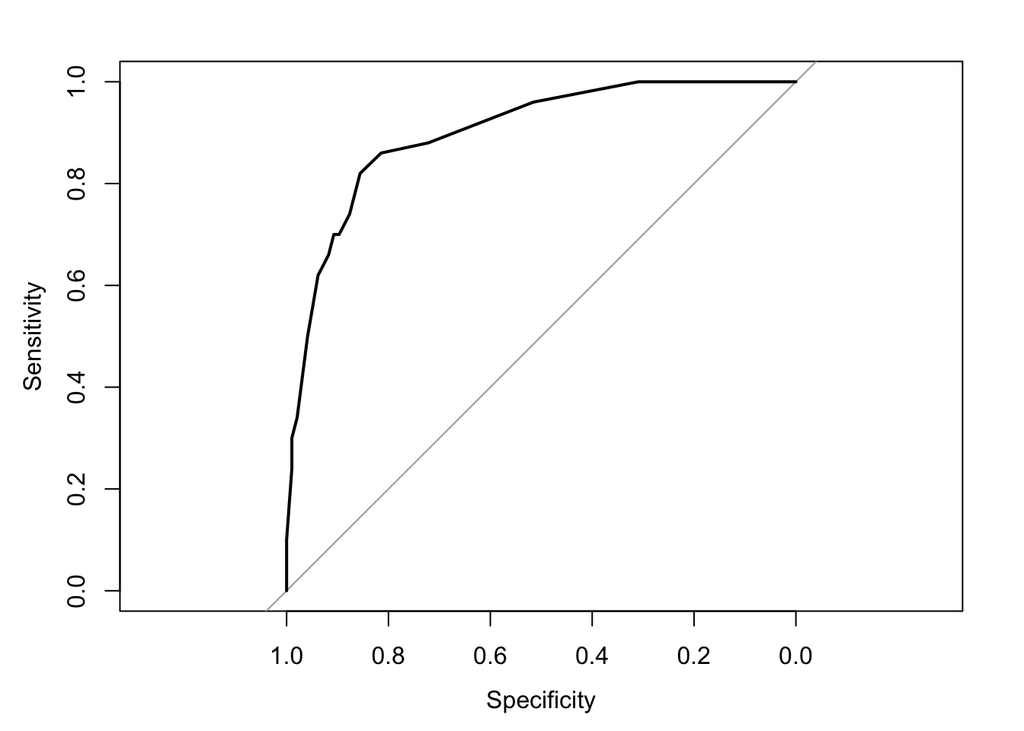

```
##
## Call:
## roc.formula(formula = death ~ prob, data = sas_datasets[["penalty"]])
##
## Data: prob in 97 controls (death 0) < 50 cases (death 1).
## Area under the curve: 0.9
```

```r
output3.17 <- glm(
  formula = death ~ blackd + whitvic + culp,
  data = sas_datasets[['penalty']],
  family = binomial()
)

sas_datasets[['penalty']]$prob <- predict(output3.17,type= 'response')
roc_penalty <- roc(death ~ prob, data = sas_datasets[['penalty']])
plot(roc_penalty)
```

With `ROCR` package

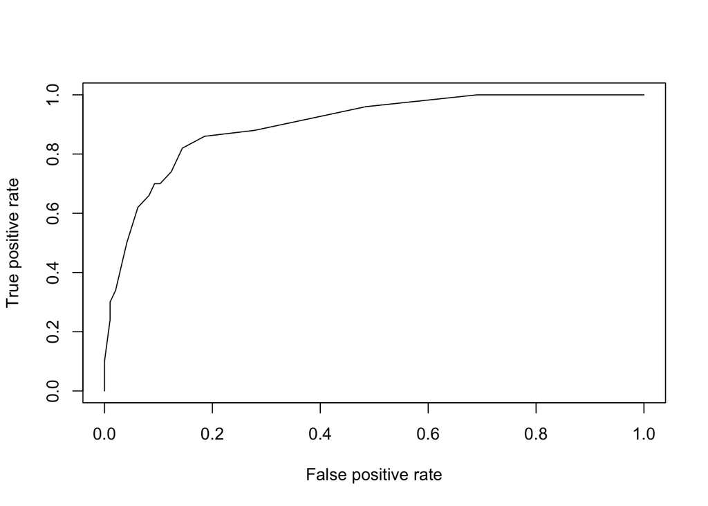

```
/* The following program is found on page 78 */
PROC LOGISTIC DATA=penalty;
  MODEL death(EVENT='1')=blackd whitvic culp;
  ROC 'omit culp' blackd whitvic;
  ROC 'omit blackd' whitvic culp;
  ROC 'omit whitvic' blackd culp;
  ROCCONTRAST / ESTIMATE=ALLPAIRS;
RUN;
```

```r
rocr_example <- prediction(sas_datasets[['penalty']]$prob,
                           sas_datasets[['penalty']]$death)
rocr_perf <- performance(rocr_example,"tpr","fpr")
plot(rocr_perf)
```

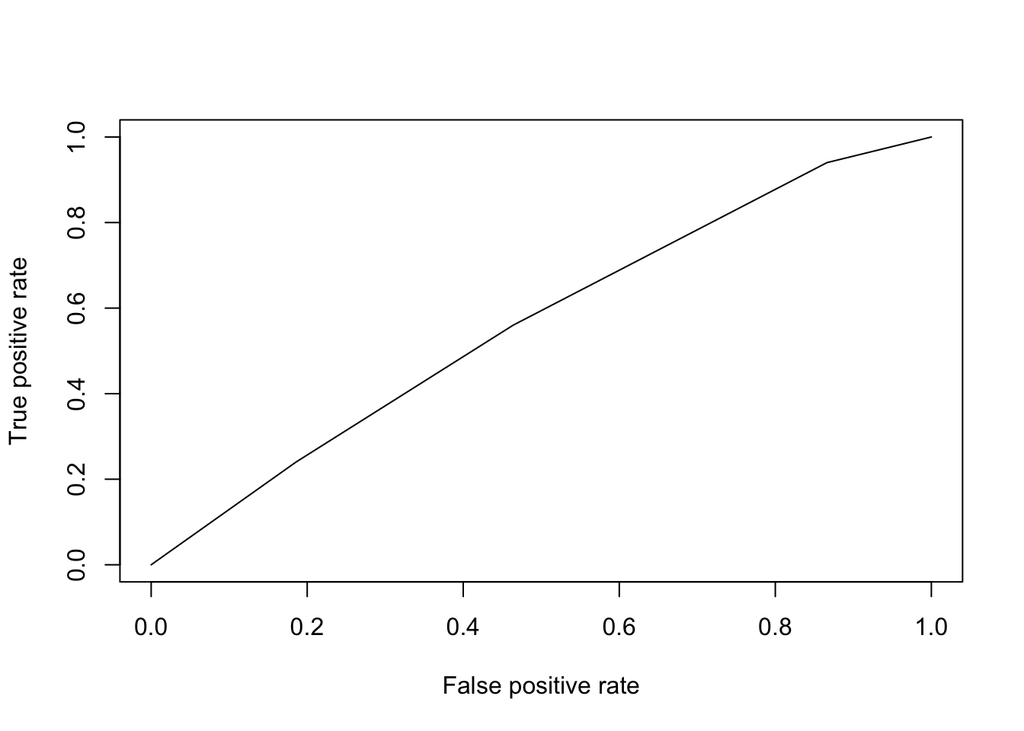

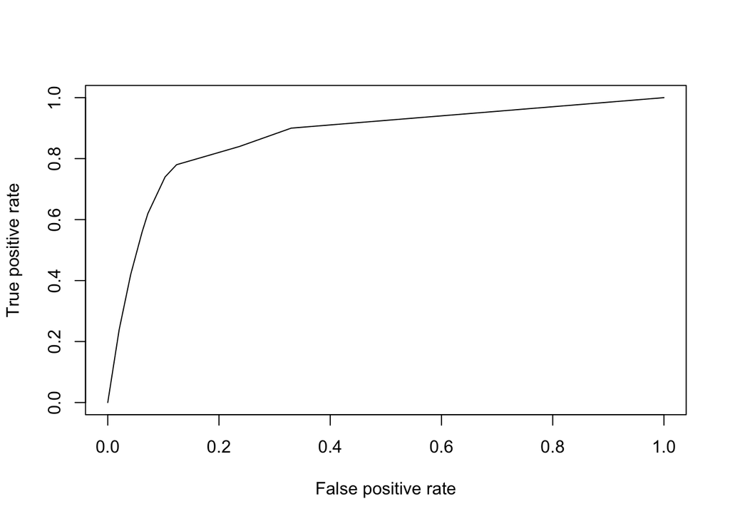

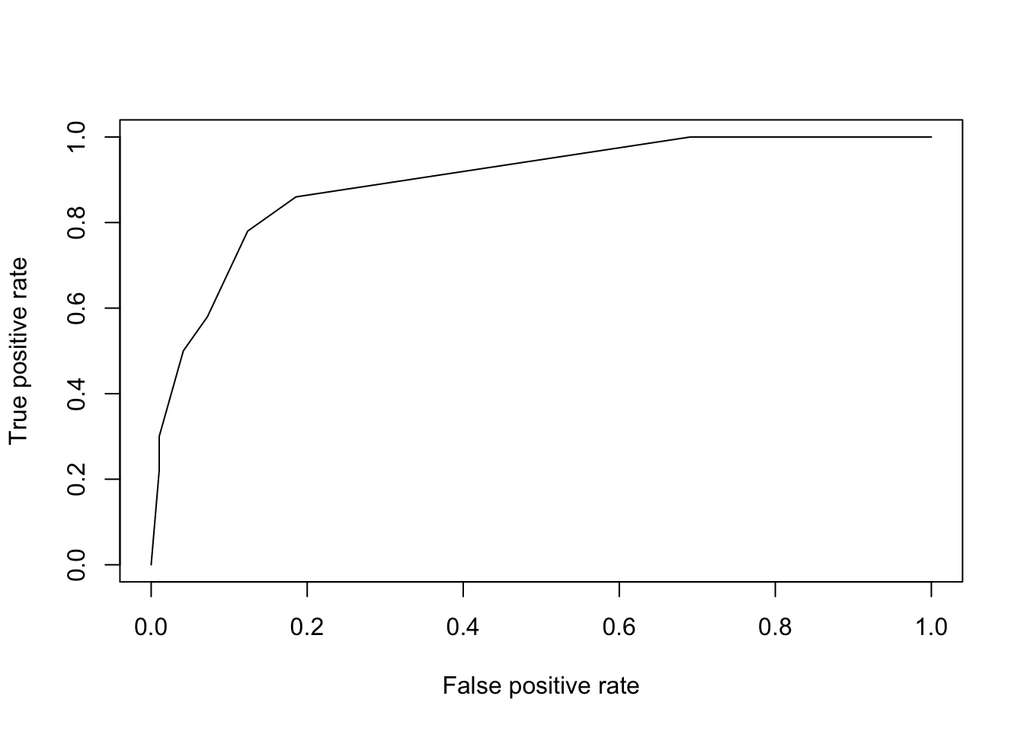

```r
output3.17_1 <- glm(
  formula = death ~ blackd + whitvic ,
  data = sas_datasets[['penalty']],
  family = binomial()
)
output3.17_2 <- glm(
  formula = death ~  whitvic + culp,
  data = sas_datasets[['penalty']],
  family = binomial()
)
output3.17_3 <- glm(
  formula = death ~ blackd + culp,
  data = sas_datasets[['penalty']],
  family = binomial()
)
sas_datasets[['penalty']]$prob1 <- predict(output3.17_1,type= 'response')
sas_datasets[['penalty']]$prob2 <- predict(output3.17_2,type= 'response')
sas_datasets[['penalty']]$prob3 <- predict(output3.17_3,type= 'response')

### ROCR
perfs <- list()
for (c in paste0('prob', 1:3)) {
  rocr_example <- prediction(sas_datasets[['penalty']][, c],
  sas_datasets[['penalty']]$death)
  perfs[[c]] <- performance(rocr_example, "tpr", "fpr")
}
lapply(perfs,plot)
```

```r
### pROC
roc_penalty1 <- roc(sas_datasets[['penalty']]$death,
                   sas_datasets[['penalty']]$prob1)
roc_penalty2 <- roc(sas_datasets[['penalty']]$death,
                   sas_datasets[['penalty']]$prob2)
roc_penalty3 <- roc(sas_datasets[['penalty']]$death,
                   sas_datasets[['penalty']]$prob3)

plot(roc_penalty1,col= 'red')
```

```
##
## Call:
## roc.default(response = sas_datasets[["penalty"]]$death, predictor = sas_datasets[["penalty"]]$prob1)
##
## Data: sas_datasets[["penalty"]]$prob1 in 97 controls (sas_datasets[["penalty"]]$death 0) < 50 cases (sas_datasets[["penalty"]]$death 1).
## Area under the curve: 0.5652
```

```r
plot(roc_penalty2,col= 'blue',add=T)
```

```
##
## Call:
## roc.default(response = sas_datasets[["penalty"]]$death, predictor = sas_datasets[["penalty"]]$prob2)
##
## Data: sas_datasets[["penalty"]]$prob2 in 97 controls (sas_datasets[["penalty"]]$death 0) < 50 cases (sas_datasets[["penalty"]]$death 1).
## Area under the curve: 0.8713
```

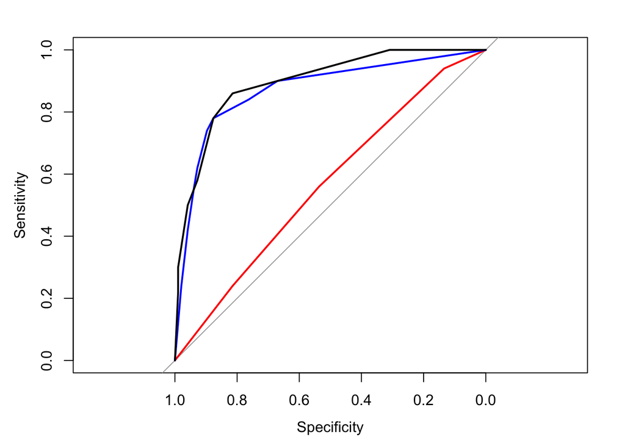

```
##
## Call:
## roc.default(response = sas_datasets[["penalty"]]$death, predictor = sas_datasets[["penalty"]]$prob3)
##
## Data: sas_datasets[["penalty"]]$prob3 in 97 controls (sas_datasets[["penalty"]]$death 0) < 50 cases (sas_datasets[["penalty"]]$death 1).
## Area under the curve: 0.8951
```

```r
plot(roc_penalty3,col= 'black',add=T)
```

Comparing ROC curves by test. SAS in ROCCONTRAST is using Delong method. This method is default for `pROC` package.

```r
roc.test(roc_penalty1,roc_penalty2)
```

```
##
##  DeLong's test for two correlated ROC curves
##
## data:  roc_penalty1 and roc_penalty2
## Z = -4.8072, p-value = 1.531e-06
## alternative hypothesis: true difference in AUC is not equal to 0
## sample estimates:
## AUC of roc1 AUC of roc2
##   0.5651546   0.8713402
```

```r
### the same as above
roc.test(death ~ prob1 + prob2, data = sas_datasets[['penalty']])
```

```
##
##  DeLong's test for two correlated ROC curves
##
## data:  prob1 and prob2 in sas_datasets[["penalty"]] by death (0, 1)
## Z = -4.8072, p-value = 1.531e-06
## alternative hypothesis: true difference in AUC is not equal to 0
## sample estimates:
## AUC of roc1 AUC of roc2
##   0.5651546   0.8713402
```

```r
roc.test(death ~ prob1 + prob3, data = sas_datasets[['penalty']])
```

```
##
##  DeLong's test for two correlated ROC curves
##
## data:  prob1 and prob3 in sas_datasets[["penalty"]] by death (0, 1)
## Z = -5.8277, p-value = 5.62e-09
## alternative hypothesis: true difference in AUC is not equal to 0
## sample estimates:
## AUC of roc1 AUC of roc2
##   0.5651546   0.8950515
```

```r
roc.test(death ~ prob2 + prob3, data = sas_datasets[['penalty']])
```

```
##
##  DeLong's test for two correlated ROC curves
##
## data:  prob2 and prob3 in sas_datasets[["penalty"]] by death (0, 1)
## Z = -1.7644, p-value = 0.07767
## alternative hypothesis: true difference in AUC is not equal to 0
## sample estimates:
## AUC of roc1 AUC of roc2
##   0.8713402   0.8950515
```

### Output 3.9 – Influence measures

```
/* The following program is found on page 82 */
PROC LOGISTIC DATA=penalty PLOTS(UNPACK LABEL)=
    (INFLUENCE DFBETAS PHAT DPC LEVERAGE);
  MODEL death(EVENT='1')=blackd whitvic culp ;
RUN;
```

```r
inf_meas <- influence.measures(output3.15)
str(inf_meas,1)
```

```
## List of 3
##  $ infmat: num [1:147, 1:11] -0.0339 0.1243 -0.0411 0.0339 0.0668 ...
##   ..- attr(*, "dimnames")=List of 2
##  $ is.inf: logi [1:147, 1:11] FALSE FALSE FALSE FALSE FALSE FALSE ...
##   ..- attr(*, "dimnames")=List of 2
##  $ call  : language glm(formula = death ~ blackd + whitvic + culp, family = binomial(),      data = sas_datasets[["penalty"]])
##  - attr(*, "class")= chr "infl"
```

### Ouput 3.10 – link functions

```r
output3.10_logit <- glm(
  formula = death ~ blackd + whitvic + as.numeric(culp),
  data = sas_datasets[['penalty']],
  family = binomial(link = 'logit')
)
output3.10_probit <- glm(
  formula = death ~ blackd + whitvic + as.numeric(culp),
  data = sas_datasets[['penalty']],
  family = binomial(link = 'probit')
)
output3.10_cloglog  <- glm(
  formula = death ~ blackd + whitvic + as.numeric(culp),
  data = sas_datasets[['penalty']],
  family = binomial(link = 'cloglog')
)
d <- sjt.glm(
  output3.10_logit,
  output3.10_probit,
  output3.10_cloglog,
  show.aic = TRUE,
  no.output = TRUE
  )
cat(d$knitr[[1]])
```

|  |  | death |  |  |  | death |  |  |  | death |  |  |
| --- | --- | --- | --- | --- | --- | --- | --- | --- | --- | --- | --- | --- |
|  |  | OR | CI | p |  | OR | CI | p |  | OR | CI | p |
| (Intercept) |  | 0.18 | 0.06 – 0.55 | **.003** |  | 0.37 | 0.19 – 0.70 | **.004** |  | 0.16 | 0.06 – 0.41 | **<.001** |
| blackd |  | 1.77 | 0.83 – 3.83 | .141 |  | 1.41 | 0.89 – 2.24 | .143 |  | 1.61 | 0.87 – 2.98 | .130 |
| whitvic |  | 1.39 | 0.65 – 3.04 | .407 |  | 1.22 | 0.76 – 1.95 | .407 |  | 1.30 | 0.71 – 2.45 | .404 |
| as.numeric(culp) |  | 1.24 | 0.92 – 1.69 | .157 |  | 1.13 | 0.95 – 1.35 | .197 |  | 1.25 | 0.95 – 1.62 | .059 |
| Observations |  | 147 |  |  |  | 147 |  |  |  | 147 |  |  |
| AIC |  | 192.516 |  |  |  | 192.692 |  |  |  | 191.937 |  |  |

### Summary of GLM – using `sjPlot` package

```r
output3.10_logit <- glm(
  formula = death ~ blackd + whitvic + culp,
  data = sas_datasets[['penalty']],
  family = binomial(link = 'logit')
)

results_sjplot <- sjt.glm(
  output3.10_logit,
  show.aic = TRUE,
  no.output = TRUE,
  show.se = TRUE,
  show.r2 = TRUE,
  show.icc = TRUE,
  show.re.var = TRUE,
  show.loglik = TRUE,
  show.aicc = TRUE,
  show.dev = TRUE,
  #show.hoslem = TRUE,
  show.family = TRUE,
  show.chi2 = TRUE
  )
cat(results_sjplot$knitr[[1]])
```

|  |  | death |  |  |  |
| --- | --- | --- | --- | --- | --- |
|  |  | OR | CI | std. Error | p |
| (Intercept) |  | 1.74 | 0.45 – 7.61 | 0.70 | .431 |
| blackd |  | 5.61 | 1.80 – 20.40 | 0.61 | **.005** |
| whitvic |  | 2.31 | 0.77 – 7.39 | 0.57 | .141 |
| culp |  |  |  |  |  |
| 2 |  | 0.01 | 0.00 – 0.03 | 0.83 | **<.001** |
| 3 |  | 0.05 | 0.01 – 0.19 | 0.78 | **<.001** |
| 4 |  | 0.22 | 0.04 – 1.10 | 0.84 | .069 |
| 5 |  | 0.70 | 0.12 – 4.32 | 0.89 | .684 |
| Observations |  | 147 |  |  |  |
| Pseudo-R<sup>2</sup> |  | R<sup>2</sup><sub>CS</sub> = .421 R<sup>2</sup><sub>N</sub> = .582 D = .491 |  |  |  |
| AIC |  | 122.224 |  |  |  |
| AICc |  | 123.030 |  |  |  |
| -2 Log-Likelihood |  | 108.224 |  |  |  |
| Deviance |  | 108.224 |  |  |  |
| Χ<sup>2</sup><sub>deviance</sub> |  | p=.000 |  |  |  |
| Family |  | binomial (logit) |  |  |  |

### Output 3.12 – Heterogenity ?

## Chapter 8 – Logit analysis of longitudinal and other clustered data

### Output 8.1 – first cases of PTSD dataset

```r
head(sas_datasets[['ptsd']])
```

```
## # A tibble: 6 x 7
##   subjid  ptsd  control problems sevent cohes  time
##    <dbl> <dbl>    <dbl>    <dbl>  <dbl> <dbl> <dbl>
## 1     15     0 3.222222    5.625      1     8     1
## 2     15     0 3.166667    5.375      0     8     2
## 3     15     0 3.277778    3.750      1     8     3
## 4     18     1 2.555556    9.250      0     8     1
## 5     18     0 3.444444    4.375      0     8     2
## 6     18     0 3.333333    2.375      0     8     3
```

### Output 8.2 – logistic regression for PTSD data

```
/* The following program is found on page 220 */
PROC LOGISTIC DATA=ptsd;
  CLASS time / PARAM=GLM;
  MODEL ptsd(EVENT='1') = control problems sevent cohes time;
RUN;
```

```r
sas_datasets[['ptsd']]$time <- factor(sas_datasets[['ptsd']]$time)
sas_datasets[['ptsd']]$time <- relevel(sas_datasets[['ptsd']]$time,ref='3')

output8.2 <- lrm(
  formul = ptsd ~ control + problems + sevent + cohes + time,
  data = sas_datasets[['ptsd']]
)
output8.2
```

```
##
## Logistic Regression Model
##
## lrm(formula = ptsd ~ control + problems + sevent + cohes + time,
##     data = sas_datasets[["ptsd"]])
##                        Model Likelihood    Discrimination    Rank Discrim.
##                              Ratio Test           Indexes          Indexes
## Obs           948    LR chi2     207.16    R2       0.276    C       0.777
##  0            654    d.f.             6    g        1.366    Dxy     0.553
##  1            294    Pr(> chi2) <0.0001    gr       3.921    gamma   0.555
## max |deriv| 2e-10                          gp       0.237    tau-a   0.237
##                                            Brier    0.170
##
##           Coef    S.E.   Wald Z Pr(>|Z|)
## Intercept  1.4246 0.8287  1.72  0.0856
## control   -0.9594 0.2047 -4.69  <0.0001
## problems   0.2956 0.0505  5.86  <0.0001
## sevent     0.3557 0.0804  4.43  <0.0001
## cohes     -0.1782 0.0373 -4.78  <0.0001
## time=1     0.3566 0.2055  1.74  0.0827
## time=2     0.2499 0.2041  1.22  0.2208
```

Check association between Symptoms of PTSD at Adjacent Time Periods

```r
sas_datasets[['ptsd']] %>%
  dplyr::select(subjid,time,ptsd) %>%
  spread(time, ptsd, fill = 0, sep = '_') %>%
  count(time_1,time_2,time_3) %>%
  kable()
```

| time_1 | time_2 | time_3 | n |
| --- | --- | --- | --- |
| 0 | 0 | 0 | 144 |
| 0 | 0 | 1 | 10 |
| 0 | 1 | 0 | 22 |
| 0 | 1 | 1 | 11 |
| 1 | 0 | 0 | 55 |
| 1 | 0 | 1 | 13 |
| 1 | 1 | 0 | 24 |
| 1 | 1 | 1 | 37 |

### Output 8.3 – proc surveylogistic output with robust standard errors

```
/* The following program is found on page 222 */
PROC SURVEYLOGISTIC DATA=ptsd;
  CLASS time / PARAM=GLM;
  MODEL ptsd(EVENT='1') = control problems sevent cohes time;
  CLUSTER subjid;
RUN;
```

The same using `survey` package. First we need to define `design` object.

```r
des1 <- svydesign(ids =  ~ subjid,
                  data = sas_datasets[['ptsd']],
                  weights= ~1)
des1
```

```
## 1 - level Cluster Sampling design (with replacement)
## With (316) clusters.
## svydesign(ids = ~subjid, data = sas_datasets[["ptsd"]], weights = ~1)
```

```r
res_svylog <- svyglm(
  formul = ptsd ~ control + problems + sevent + cohes + time,
  design = des1,
  family = binomial()
)

summary(res_svylog)
```

```
##
## Call:
## svyglm(formul = ptsd ~ control + problems + sevent + cohes +
##     time, design = des1, family = binomial())
##
## Survey design:
## svydesign(ids = ~subjid, data = sas_datasets[["ptsd"]], weights = ~1)
##
## Coefficients:
##             Estimate Std. Error t value Pr(>|t|)
## (Intercept)  1.42460    0.90367   1.576 0.115943
## control     -0.95937    0.22741  -4.219 3.23e-05 ***
## problems     0.29559    0.05154   5.736 2.31e-08 ***
## sevent       0.35572    0.09015   3.946 9.84e-05 ***
## cohes       -0.17823    0.04671  -3.815 0.000164 ***
## time1        0.35660    0.18411   1.937 0.053668 .
## time2        0.24990    0.17229   1.450 0.147936
## ---
## Signif. codes:  0 '***' 0.001 '**' 0.01 '*' 0.05 '.' 0.1 ' ' 1
##
## (Dispersion parameter for binomial family taken to be 0.964069)
##
## Number of Fisher Scoring iterations: 5
```

**SURVEY STANDARD ERRORS ARE DIFFERENT**

### Output 8.4 – proc genmod – comparison of results

SAS code:

```
/* The following program is found on page 224 */
PROC GENMOD DATA=ptsd DESC;
  CLASS subjid time;
  MODEL ptsd = control problems sevent cohes time /
    DIST=BINOMIAL TYPE3;
  REPEATED SUBJECT=subjid;
RUN;
```

Now, do the same in R with `gee` and `geepack` packages

```r
gee_output8.4 <- gee(
  formula = ptsd ~ control + problems + sevent + cohes + time,
  family = binomial(),
  data = sas_datasets[['ptsd']],
  id = subjid
)
```

```
## (Intercept)     control    problems      sevent       cohes       time1
##   1.4245959  -0.9593727   0.2955913   0.3557214  -0.1782289   0.3565999
##       time2
##   0.2499002
```

```r
## without initial values for betas
summary(gee_output8.4)
```

```
##
##  GEE:  GENERALIZED LINEAR MODELS FOR DEPENDENT DATA
##  gee S-function, version 4.13 modified 98/01/27 (1998)
##
## Model:
##  Link:                      Logit
##  Variance to Mean Relation: Binomial
##  Correlation Structure:     Independent
##
## Call:
## gee(formula = ptsd ~ control + problems + sevent + cohes + time,
##     id = subjid, data = sas_datasets[["ptsd"]], family = binomial())
##
## Summary of Residuals:
##        Min         1Q     Median         3Q        Max
## -0.8630474 -0.2784585 -0.1081989  0.3545375  0.9384132
##
##
## Coefficients:
##               Estimate Naive S.E.   Naive z Robust S.E.  Robust z
## (Intercept)  1.4245959 0.81625400  1.745285  0.90223720  1.578959
## control     -0.9593727 0.20158305 -4.759193  0.22704996 -4.225381
## problems     0.2955913 0.04970898  5.946437  0.05145466  5.744695
## sevent       0.3557214 0.07916276  4.493544  0.09000360  3.952302
## cohes       -0.1782289 0.03671960 -4.853780  0.04663983 -3.821387
## time1        0.3565999 0.20240459  1.761817  0.18381625  1.939980
## time2        0.2499002 0.20103299  1.243081  0.17201366  1.452793
##
## Estimated Scale Parameter:  0.9702486
## Number of Iterations:  1
##
## Working Correlation
##      [,1] [,2] [,3]
## [1,]    1    0    0
## [2,]    0    1    0
## [3,]    0    0    1
```

```r
## with initial values for betas
gee_output8.4 <- gee(
  formula = ptsd ~ control + problems + sevent + cohes + time,
  family = binomial(),
  data = sas_datasets[['ptsd']],
  id = subjid,
  b= coef(res_svylog)
)
```

```
##            [,1]
## [1,]  1.4245959
## [2,] -0.9593727
## [3,]  0.2955913
## [4,]  0.3557214
## [5,] -0.1782289
## [6,]  0.3565999
## [7,]  0.2499002
```

```r
summary(gee_output8.4)
```

```
##
##  GEE:  GENERALIZED LINEAR MODELS FOR DEPENDENT DATA
##  gee S-function, version 4.13 modified 98/01/27 (1998)
##
## Model:
##  Link:                      Logit
##  Variance to Mean Relation: Binomial
##  Correlation Structure:     Independent
##
## Call:
## gee(formula = ptsd ~ control + problems + sevent + cohes + time,
##     id = subjid, data = sas_datasets[["ptsd"]], b = coef(res_svylog),
##     family = binomial())
##
## Summary of Residuals:
##        Min         1Q     Median         3Q        Max
## -0.8630474 -0.2784585 -0.1081989  0.3545375  0.9384132
##
##
## Coefficients:
##               Estimate Naive S.E.   Naive z Robust S.E.  Robust z
## (Intercept)  1.4245959 0.81625400  1.745285  0.90223720  1.578959
## control     -0.9593727 0.20158305 -4.759193  0.22704996 -4.225381
## problems     0.2955913 0.04970898  5.946437  0.05145466  5.744695
## sevent       0.3557214 0.07916276  4.493544  0.09000360  3.952302
## cohes       -0.1782289 0.03671960 -4.853780  0.04663983 -3.821387
## time1        0.3565999 0.20240459  1.761817  0.18381625  1.939980
## time2        0.2499002 0.20103299  1.243081  0.17201366  1.452793
##
## Estimated Scale Parameter:  0.9702486
## Number of Iterations:  1
##
## Working Correlation
##      [,1] [,2] [,3]
## [1,]    1    0    0
## [2,]    0    1    0
## [3,]    0    0    1
```

Now compare results with `geepack` package

```r
geepack_output8.4 <- geeglm(
  formula = ptsd ~ control + problems + sevent + cohes + time,
  family = binomial(),
  data = sas_datasets[['ptsd']],
  id = subjid
)
summary(geepack_output8.4)
```

```
##
## Call:
## geeglm(formula = ptsd ~ control + problems + sevent + cohes +
##     time, family = binomial(), data = sas_datasets[["ptsd"]],
##     id = subjid)
##
##  Coefficients:
##             Estimate  Std.err   Wald Pr(>|W|)
## (Intercept)  1.42460  0.90224  2.493 0.114345
## control     -0.95937  0.22705 17.854 2.39e-05 ***
## problems     0.29559  0.05145 33.002 9.21e-09 ***
## sevent       0.35572  0.09000 15.621 7.74e-05 ***
## cohes       -0.17823  0.04664 14.603 0.000133 ***
## time1        0.35660  0.18382  3.764 0.052382 .
## time2        0.24990  0.17201  2.111 0.146281
## ---
## Signif. codes:  0 '***' 0.001 '**' 0.01 '*' 0.05 '.' 0.1 ' ' 1
##
## Estimated Scale Parameters:
##             Estimate Std.err
## (Intercept)   0.9631  0.1197
##
## Correlation: Structure = independenceNumber of clusters:   316   Maximum cluster size: 3
```

```r
anova(geepack_output8.4)
```

```
## Analysis of 'Wald statistic' Table
## Model: binomial, link: logit
## Response: ptsd
## Terms added sequentially (first to last)
##
##          Df   X2 P(>|Chi|)
## control   1 72.4   < 2e-16 ***
## problems  1 48.5   3.3e-12 ***
## sevent    1 15.6   7.9e-05 ***
## cohes     1 14.3   0.00016 ***
## time      2  4.0   0.13354
## ---
## Signif. codes:  0 '***' 0.001 '**' 0.01 '*' 0.05 '.' 0.1 ' ' 1
```

### Output 8.6 – proc genmod – introducing correlation structure

```
/* The following program is found on page 227 */
PROC GENMOD DATA=ptsd DESC;
  CLASS subjid time;
  MODEL ptsd = control problems sevent cohes time / D=B;
  REPEATED SUBJECT=subjid / WITHIN=time TYPE=UN CORRW;
RUN;
```

```r
geepack_output8.6 <- geeglm(
  formula = ptsd ~ control + problems + sevent + cohes + time,
  family = binomial(),
  data = sas_datasets[['ptsd']],
  id = subjid,
  corstr = 'unstructured'
)
summary(geepack_output8.6)
```

```
##
## Call:
## geeglm(formula = ptsd ~ control + problems + sevent + cohes +
##     time, family = binomial(), data = sas_datasets[["ptsd"]],
##     id = subjid, corstr = "unstructured")
##
##  Coefficients:
##             Estimate Std.err  Wald Pr(>|W|)
## (Intercept)   1.6071  0.8682  3.43   0.0642 .
## control      -0.9086  0.2157 17.74  2.5e-05 ***
## problems      0.2565  0.0500 26.30  2.9e-07 ***
## sevent        0.2751  0.0866 10.09   0.0015 **
## cohes        -0.1908  0.0455 17.55  2.8e-05 ***
## time1         0.4153  0.1782  5.43   0.0197 *
## time2         0.2714  0.1664  2.66   0.1029
## ---
## Signif. codes:  0 '***' 0.001 '**' 0.01 '*' 0.05 '.' 0.1 ' ' 1
##
## Estimated Scale Parameters:
##             Estimate Std.err
## (Intercept)    0.939   0.105
##
## Correlation: Structure = unstructured  Link = identity
##
## Estimated Correlation Parameters:
##           Estimate Std.err
## alpha.1:2    0.186  0.0673
## alpha.1:3    0.250  0.0686
## alpha.2:3    0.382  0.0872
## Number of clusters:   316   Maximum cluster size: 3
```

```r
anova(geepack_output8.6)
```

```
## Analysis of 'Wald statistic' Table
## Model: binomial, link: logit
## Response: ptsd
## Terms added sequentially (first to last)
##
##          Df   X2 P(>|Chi|)
## control   1 67.1   2.2e-16 ***
## problems  1 44.2   2.9e-11 ***
## sevent    1 10.4    0.0013 **
## cohes     1 16.2   5.6e-05 ***
## time      2  5.7    0.0585 .
## ---
## Signif. codes:  0 '***' 0.001 '**' 0.01 '*' 0.05 '.' 0.1 ' ' 1
```

### Output 8.7 – proc genmod – introducing correlation structure

```
/* The following program is found on page 227 */
PROC GENMOD DATA=ptsd DESC;
  CLASS subjid time;
  MODEL ptsd = control problems sevent cohes time / D=B;
  REPEATED SUBJECT=subjid / WITHIN=time TYPE=EXCH CORRW;
RUN;
```

```r
geepack_output8.7 <- geeglm(
  formula = ptsd ~ control + problems + sevent + cohes + time,
  family = binomial(),
  data = sas_datasets[['ptsd']],
  id = subjid,
  corstr = 'exchangeable'
)
summary(geepack_output8.7)
```

```
##
## Call:
## geeglm(formula = ptsd ~ control + problems + sevent + cohes +
##     time, family = binomial(), data = sas_datasets[["ptsd"]],
##     id = subjid, corstr = "exchangeable")
##
##  Coefficients:
##             Estimate Std.err  Wald Pr(>|W|)
## (Intercept)   1.7927  0.8619  4.33   0.0375 *
## control      -0.9601  0.2147 19.99  7.8e-06 ***
## problems      0.2497  0.0497 25.24  5.0e-07 ***
## sevent        0.2810  0.0864 10.57   0.0011 **
## cohes        -0.1871  0.0451 17.20  3.4e-05 ***
## time1         0.4100  0.1782  5.29   0.0214 *
## time2         0.2699  0.1662  2.64   0.1043
## ---
## Signif. codes:  0 '***' 0.001 '**' 0.01 '*' 0.05 '.' 0.1 ' ' 1
##
## Estimated Scale Parameters:
##             Estimate Std.err
## (Intercept)    0.939   0.103
##
## Correlation: Structure = exchangeable  Link = identity
##
## Estimated Correlation Parameters:
##       Estimate Std.err
## alpha    0.273  0.0613
## Number of clusters:   316   Maximum cluster size: 3
```

```r
anova(geepack_output8.7)
```

```
## Analysis of 'Wald statistic' Table
## Model: binomial, link: logit
## Response: ptsd
## Terms added sequentially (first to last)
##
##          Df   X2 P(>|Chi|)
## control   1 69.9   < 2e-16 ***
## problems  1 42.1   8.7e-11 ***
## sevent    1 10.5    0.0012 **
## cohes     1 15.8   6.9e-05 ***
## time      2  5.6    0.0623 .
## ---
## Signif. codes:  0 '***' 0.001 '**' 0.01 '*' 0.05 '.' 0.1 ' ' 1
```

Robust standard errors in GEE are better because:

- are robust for model misspecification
- are better for bigger sample sizes, especially when time series is longer

### Output 8.8 – proc genmod – MDEP correlation structure

```
/* The following program is found on page 227 */
PROC GENMOD DATA=ptsd DESC;
  CLASS subjid time;
  MODEL ptsd = control problems sevent cohes time / D=B;
  REPEATED SUBJECT=subjid / WITHIN=time TYPE=MDEP(2) CORRW;
RUN;
```

Package `geepack` do not have MDEP correlation structures, now we should use `gee`.

```r
gee_output8.8 <- gee(
  formula = ptsd ~ control + problems + sevent + cohes + time,
  family = binomial(),
  data = sas_datasets[['ptsd']],
  id = subjid,
  corstr = 'stat_M_dep',
  Mv = 2
)
```

```
## (Intercept)     control    problems      sevent       cohes       time1
##       1.425      -0.959       0.296       0.356      -0.178       0.357
##       time2
##       0.250
```

```r
summary(gee_output8.8)
```

```
##
##  GEE:  GENERALIZED LINEAR MODELS FOR DEPENDENT DATA
##  gee S-function, version 4.13 modified 98/01/27 (1998)
##
## Model:
##  Link:                      Logit
##  Variance to Mean Relation: Binomial
##  Correlation Structure:     Stationary M-dependent , M = 2
##
## Call:
## gee(formula = ptsd ~ control + problems + sevent + cohes + time,
##     id = subjid, data = sas_datasets[["ptsd"]], family = binomial(),
##     corstr = "stat_M_dep", Mv = 2)
##
## Summary of Residuals:
##    Min     1Q Median     3Q    Max
## -0.846 -0.274 -0.121  0.379  0.933
##
##
## Coefficients:
##             Estimate Naive S.E. Naive z Robust S.E. Robust z
## (Intercept)    1.770     0.8384    2.11      0.8606     2.06
## control       -0.953     0.2057   -4.63      0.2147    -4.44
## problems       0.250     0.0507    4.92      0.0495     5.04
## sevent         0.278     0.0764    3.64      0.0863     3.23
## cohes         -0.187     0.0442   -4.23      0.0451    -4.15
## time1          0.412     0.1773    2.32      0.1783     2.31
## time2          0.270     0.1671    1.62      0.1660     1.63
##
## Estimated Scale Parameter:  0.945
## Number of Iterations:  3
##
## Working Correlation
##       [,1]  [,2]  [,3]
## [1,] 1.000 0.284 0.251
## [2,] 0.284 1.000 0.284
## [3,] 0.251 0.284 1.000
```

Which correlation matrix when?

- unstructured – if time points is relativly small ( <=4)
- MDEP / AR1 – when there is a trend
- exchangable – when you are modelling students within schools or pople within neighborhoods because there is no natural order

GEE vs Mixed models:

- mixed models can have more complex structures than gee model (multiple levels of clusters, overlapping clusters, random coefficients)
- mixed models can correct for heterogenity shrinkage – models are subject specific rather than populatio averaged

### Output 8.11 – Mixed models

```
/* The following program is found on page 235 */
PROC GLIMMIX DATA=ptsd METHOD=QUAD;
  CLASS subjid time;
  MODEL ptsd = control problems sevent cohes time / D=B
     SOLUTION;
  RANDOM INTERCEPT / SUBJECT=subjid;
  COVTEST 0;
RUN;
```

Now do the same using `MASS` (based on `nlme`), `glmmML` and `lme4` packages

```r
glmmPQL_output8.11 <- glmmPQL(
  fixed = ptsd ~ control + problems + sevent + cohes + time,
  family = binomial(),
  random = ~ 1 | subjid,
  data = sas_datasets[['ptsd']],
  verbose = F)
summary(glmmPQL_output8.11)
```

```
## Linear mixed-effects model fit by maximum likelihood
##  Data: sas_datasets[["ptsd"]]
##   AIC BIC logLik
##    NA  NA     NA
##
## Random effects:
##  Formula: ~1 | subjid
##         (Intercept) Residual
## StdDev:         1.6    0.741
##
## Variance function:
##  Structure: fixed weights
##  Formula: ~invwt
## Fixed effects: ptsd ~ control + problems + sevent + cohes + time
##              Value Std.Error  DF t-value p-value
## (Intercept)  2.401     0.966 627    2.49  0.0132
## control     -1.258     0.236 627   -5.34  0.0000
## problems     0.309     0.057 627    5.42  0.0000
## sevent       0.334     0.086 627    3.88  0.0001
## cohes       -0.235     0.056 314   -4.16  0.0000
## time1        0.617     0.191 627    3.22  0.0013
## time2        0.375     0.180 627    2.09  0.0373
##  Correlation:
##          (Intr) contrl prblms sevent cohes  time1
## control  -0.841
## problems -0.516  0.247
## sevent   -0.077  0.005 -0.048
## cohes    -0.297 -0.139  0.042  0.005
## time1    -0.022  0.079 -0.378  0.085 -0.082
## time2    -0.031 -0.021 -0.176  0.113 -0.019  0.579
##
## Standardized Within-Group Residuals:
##    Min     Q1    Med     Q3    Max
## -3.079 -0.532 -0.284  0.504  3.037
##
## Number of Observations: 948
## Number of Groups: 316
```

```r
glmmml_output8.11 <- glmmML(
  formula = ptsd ~ control + problems + sevent + cohes + time,
  family = binomial(),
  cluster = subjid,
  data = sas_datasets[['ptsd']],
  prior = 'gaussian',
  method = 'ghq', ## to get consistent results with SAS (Gauss-Hermite),
  n.points = 50
  )
summary(glmmml_output8.11)
```

```
##
## Call:  glmmML(formula = ptsd ~ control + problems + sevent + cohes +      time, family = binomial(), data = sas_datasets[["ptsd"]],      cluster = subjid, prior = "gaussian", method = "ghq", n.points = 50)
##
##
##               coef se(coef)     z Pr(>|z|)
## (Intercept)  2.358   1.1835  1.99  4.6e-02
## control     -1.324   0.2968 -4.46  8.2e-06
## problems     0.354   0.0705  5.03  4.9e-07
## sevent       0.402   0.1086  3.70  2.2e-04
## cohes       -0.248   0.0625 -3.96  7.4e-05
## time1        0.526   0.2518  2.09  3.7e-02
## time2        0.351   0.2394  1.47  1.4e-01
##
## Scale parameter in mixing distribution:  1.46 gaussian
## Std. Error:                              0.198
##
##         LR p-value for H_0: sigma = 0:  5.8e-11
##
## Residual deviance: 925 on 940 degrees of freedom     AIC: 941
```

```r
glmer_output8.11 <- glmer(
  formula = ptsd ~ (1 | subjid) +
  control + problems + sevent + cohes + time,
  family = binomial(),
  data = sas_datasets[['ptsd']],
  control = glmerControl(optimizer = "nloptwrap",
  calc.derivs = FALSE),
  nAGQ = 25
  )
summary(glmer_output8.11)
```

```
## Generalized linear mixed model fit by maximum likelihood (Adaptive
##   Gauss-Hermite Quadrature, nAGQ = 25) [glmerMod]
##  Family: binomial  ( logit )
## Formula: ptsd ~ (1 | subjid) + control + problems + sevent + cohes + time
##    Data: sas_datasets[["ptsd"]]
## Control: glmerControl(optimizer = "nloptwrap", calc.derivs = FALSE)
##
##      AIC      BIC   logLik deviance df.resid
##      941      980     -463      925      940
##
## Scaled residuals:
##    Min     1Q Median     3Q    Max
## -2.200 -0.431 -0.230  0.489  2.773
##
## Random effects:
##  Groups Name        Variance Std.Dev.
##  subjid (Intercept) 2.09     1.45
## Number of obs: 948, groups:  subjid, 316
##
## Fixed effects:
##             Estimate Std. Error z value Pr(>|z|)
## (Intercept)   2.2758     1.1305    2.01  0.04411 *
## control      -1.3017     0.2785   -4.67  3.0e-06 ***
## problems      0.3562     0.0691    5.16  2.5e-07 ***
## sevent        0.3998     0.1046    3.82  0.00013 ***
## cohes        -0.2458     0.0589   -4.18  3.0e-05 ***
## time1         0.5090     0.2414    2.11  0.03497 *
## time2         0.3481     0.2326    1.50  0.13453
## ---
## Signif. codes:  0 '***' 0.001 '**' 0.01 '*' 0.05 '.' 0.1 ' ' 1
##
## Correlation of Fixed Effects:
##          (Intr) contrl prblms sevent cohes  time1
## control  -0.856
## problems -0.543  0.260
## sevent   -0.077  0.000 -0.030
## cohes    -0.241 -0.140  0.020 -0.012
## time1    -0.022  0.050 -0.332  0.083 -0.083
## time2    -0.046 -0.029 -0.141  0.103 -0.017  0.581
```

### output 8.12 – random slope

```
/* The following program is found on page 238 */
PROC GLIMMIX DATA=ptsd METHOD=QUAD;
  CLASS subjid time;
  MODEL ptsd = control problems sevent cohes time / D=B S;
  RANDOM INTERCEPT sevent/ SUBJECT=subjid;
  COVTEST 0 .;
  COVTEST . 0;
RUN;
```

```r
glmer_output8.11 <- glmer(
  formula = ptsd ~ (1 + sevent | subjid) +
  control + problems +  cohes + time,
  family = binomial(),
  data = sas_datasets[['ptsd']],
  control = glmerControl(optimizer = "nloptwrap",
  calc.derivs = FALSE)
  )
summary(glmer_output8.11)
```

```
## Generalized linear mixed model fit by maximum likelihood (Laplace
##   Approximation) [glmerMod]
##  Family: binomial  ( logit )
## Formula: ptsd ~ (1 + sevent | subjid) + control + problems + cohes + time
##    Data: sas_datasets[["ptsd"]]
## Control: glmerControl(optimizer = "nloptwrap", calc.derivs = FALSE)
##
##      AIC      BIC   logLik deviance df.resid
##      951      995     -467      933      939
##
## Scaled residuals:
##    Min     1Q Median     3Q    Max
## -2.313 -0.405 -0.210  0.431  2.886
##
## Random effects:
##  Groups Name        Variance Std.Dev. Corr
##  subjid (Intercept) 1.883    1.372
##         sevent      0.946    0.972    -0.02
## Number of obs: 948, groups:  subjid, 316
##
## Fixed effects:
##             Estimate Std. Error z value Pr(>|z|)
## (Intercept)   3.1686     1.2052    2.63   0.0086 **
## control      -1.5438     0.2984   -5.17  2.3e-07 ***
## problems      0.3813     0.0746    5.11  3.2e-07 ***
## cohes        -0.2633     0.0618   -4.26  2.0e-05 ***
## time1         0.5776     0.2571    2.25   0.0247 *
## time2         0.3852     0.2472    1.56   0.1191
## ---
## Signif. codes:  0 '***' 0.001 '**' 0.01 '*' 0.05 '.' 0.1 ' ' 1
##
## Correlation of Fixed Effects:
##          (Intr) contrl prblms cohes  time1
## control  -0.859
## problems -0.544  0.248
## cohes    -0.241 -0.133  0.022
## time1    -0.009  0.042 -0.324 -0.093
## time2    -0.043 -0.034 -0.125 -0.009  0.582
```

### output 8.13 - conditional logistic regression

```
/* The following program is found on page 242 */
PROC LOGISTIC DATA=ptsd ;
  CLASS time / PARAM=GLM;
  MODEL ptsd(EVENT='1') = control problems sevent cohes time;
  STRATA subjid;
RUN;
```

```r
output8.13 <- clogit(
  formula = ptsd ~ control + problems + sevent + time + strata(subjid),
  data = sas_datasets[['ptsd']],
  method = 'exact'
)
summary(output8.13)
```

```
## Call:
## coxph(formula = Surv(rep(1, 948L), ptsd) ~ control + problems +
##     sevent + time + strata(subjid), data = sas_datasets[["ptsd"]],
##     method = "exact")
##
##   n= 948, number of events= 294
##
##            coef exp(coef) se(coef)     z Pr(>|z|)
## control  -1.098     0.333    0.422 -2.60   0.0093 **
## problems  0.214     1.238    0.103  2.08   0.0372 *
## sevent    0.203     1.225    0.134  1.51   0.1312
## time1     0.794     2.212    0.297  2.67   0.0075 **
## time2     0.436     1.547    0.260  1.68   0.0928 .
## ---
## Signif. codes:  0 '***' 0.001 '**' 0.01 '*' 0.05 '.' 0.1 ' ' 1
##
##          exp(coef) exp(-coef) lower .95 upper .95
## control      0.333      2.999     0.146     0.763
## problems     1.238      0.807     1.013     1.515
## sevent       1.225      0.817     0.941     1.593
## time1        2.212      0.452     1.236     3.961
## time2        1.547      0.646     0.930     2.574
##
## Rsquare= 0.056   (max possible= 0.269 )
## Likelihood ratio test= 55  on 5 df,   p=1.34e-10
## Wald test            = 42.6  on 5 df,   p=4.51e-08
## Score (logrank) test = 51.6  on 5 df,   p=6.47e-10
```

### output 8.14

```r
head(sas_datasets[['postdoc']])
```

```
## # A tibble: 6 x 9
##     AGE   MAR  PDOC   DOC    AG  ARTS  CITS DOCID   und
##   <dbl> <dbl> <dbl> <dbl> <dbl> <dbl> <dbl> <dbl> <dbl>
## 1    29     1     0   362     0     1     2  1402     7
## 2    32     1     1   210     0     1     4  1250     6
## 3    26     1     1   359     0     0     1  1399     6
## 4    25     1     0   181     0     0     1  1221     3
## 5    30     1     1   429     0     0     1  1469     7
## 6    28     1     1   359     0     1     0  1399     6
```

```r
names(sas_datasets[['postdoc']]) <-
  tolower(names(sas_datasets[['postdoc']]))

sas_datasets[['postdoc']] <- sas_datasets[['postdoc']] %>%
  arrange(docid)
sas_datasets[['postdoc']]$const <- 1
```

### output 8.15

```
/* The following program is found on page 246 */
PROC GENMOD DATA=postdoc DESC;
  CLASS docid;
  MODEL pdoc = age mar doc ag und arts cits / D=B;
  REPEATED SUBJECT=docid / TYPE=EXCH;
RUN;

/* The following program is found on page 246 */
PROC GENMOD DATA=postdoc DESC;
  CLASS docid;
  MODEL pdoc = age mar doc ag und arts cits / D=B;
  REPEATED SUBJECT=docid / TYPE=EXCH;
RUN;

/* The following program is found on page 248 */
PROC GLIMMIX DATA=postdoc METHOD=QUAD EMPIRICAL;
  CLASS docid;
  MODEL pdoc = age mar doc ag und arts cits / D=B S;
  RANDOM INTERCEPT / SUBJECT=docid;
  COVTEST 0;
RUN;

/* The following program is found on page 249 */
PROC LOGISTIC DATA=postdoc;
  MODEL pdoc(EVENT='1') = age mar ag und arts cits;
  STRATA docid;
RUN;
```

```r
output8.15_lrm <- lrm(
  formula = pdoc ~ age + mar + doc + ag + und + arts + cits,
  data = sas_datasets[['postdoc']]
)
output8.15_lrm
```

```
##
## Logistic Regression Model
##
## lrm(formula = pdoc ~ age + mar + doc + ag + und + arts + cits,
##     data = sas_datasets[["postdoc"]])
##                        Model Likelihood    Discrimination    Rank Discrim.
##                              Ratio Test           Indexes          Indexes
## Obs           554    LR chi2      78.90    R2       0.177    C       0.711
##  0            285    d.f.             7    g        0.950    Dxy     0.423
##  1            269    Pr(> chi2) <0.0001    gr       2.587    gamma   0.424
## max |deriv| 5e-08                          gp       0.211    tau-a   0.212
##                                            Brier    0.216
##
##           Coef    S.E.   Wald Z Pr(>|Z|)
## Intercept  2.3974 0.9092  2.64  0.0084
## age       -0.0991 0.0254 -3.90  <0.0001
## mar       -0.5645 0.2684 -2.10  0.0354
## doc        0.0027 0.0009  2.90  0.0038
## ag        -1.1070 0.2030 -5.45  <0.0001
## und        0.1215 0.0600  2.02  0.0429
## arts      -0.0739 0.0809 -0.91  0.3610
## cits      -0.0030 0.0170 -0.18  0.8593
```

```r
output8.15_gee <- geeglm(
  formula = pdoc ~ age + mar + doc + ag + und + arts + cits,
  id = docid,
  data = sas_datasets[['postdoc']],
  corstr = 'exchangeable',
  family = binomial()
)
summary(output8.15_gee)
```

```
##
## Call:
## geeglm(formula = pdoc ~ age + mar + doc + ag + und + arts + cits,
##     family = binomial(), data = sas_datasets[["postdoc"]], id = docid,
##     corstr = "exchangeable")
##
##  Coefficients:
##             Estimate  Std.err  Wald Pr(>|W|)
## (Intercept)  2.46047  0.94674  6.75   0.0094 **
## age         -0.10093  0.02462 16.81  4.1e-05 ***
## mar         -0.56107  0.26948  4.33   0.0373 *
## doc          0.00270  0.00117  5.32   0.0211 *
## ag          -0.99189  0.24507 16.38  5.2e-05 ***
## und          0.11819  0.05056  5.46   0.0194 *
## arts        -0.07256  0.08019  0.82   0.3655
## cits        -0.00341  0.01679  0.04   0.8392
## ---
## Signif. codes:  0 '***' 0.001 '**' 0.01 '*' 0.05 '.' 0.1 ' ' 1
##
## Estimated Scale Parameters:
##             Estimate Std.err
## (Intercept)    0.993   0.063
##
## Correlation: Structure = exchangeable  Link = identity
##
## Estimated Correlation Parameters:
##       Estimate Std.err
## alpha    0.037  0.0331
## Number of clusters:   106   Maximum cluster size: 53
```

```r
output8.15_glmer <- glmer(
  formula = pdoc ~ (1|docid) + age + mar + doc + ag + und + arts + cits,
  data = sas_datasets[['postdoc']],
  family = binomial(),
  control = glmerControl(optimizer = "nloptwrap",
  calc.derivs = FALSE),
  nAGQ = 50 ## for Gauss-Hermite quadrature
)
summary(output8.15_glmer)
```

```
## Generalized linear mixed model fit by maximum likelihood (Adaptive
##   Gauss-Hermite Quadrature, nAGQ = 50) [glmerMod]
##  Family: binomial  ( logit )
## Formula: pdoc ~ (1 | docid) + age + mar + doc + ag + und + arts + cits
##    Data: sas_datasets[["postdoc"]]
## Control: glmerControl(optimizer = "nloptwrap", calc.derivs = FALSE)
##
##      AIC      BIC   logLik deviance df.resid
##      701      740     -342      683      545
##
## Scaled residuals:
##    Min     1Q Median     3Q    Max
## -2.358 -0.774 -0.342  0.807  2.740
##
## Random effects:
##  Groups Name        Variance Std.Dev.
##  docid  (Intercept) 0.404    0.636
## Number of obs: 554, groups:  docid, 106
##
## Fixed effects:
##             Estimate Std. Error z value Pr(>|z|)
## (Intercept)  2.66637    0.97996    2.72   0.0065 **
## age         -0.11013    0.02686   -4.10  4.1e-05 ***
## mar         -0.58656    0.28057   -2.09   0.0366 *
## doc          0.00298    0.00125    2.39   0.0169 *
## ag          -1.01969    0.25534   -3.99  6.5e-05 ***
## und          0.12641    0.06301    2.01   0.0448 *
## arts        -0.07945    0.08557   -0.93   0.3531
## cits        -0.00413    0.01833   -0.23   0.8217
## ---
## Signif. codes:  0 '***' 0.001 '**' 0.01 '*' 0.05 '.' 0.1 ' ' 1
##
## Correlation of Fixed Effects:
##      (Intr) age    mar    doc    ag     und    arts
## age  -0.834
## mar  -0.240 -0.057
## doc  -0.381  0.065  0.068
## ag   -0.066  0.032 -0.087 -0.063
## und  -0.271 -0.012  0.050 -0.157  0.069
## arts -0.084  0.041  0.025  0.028 -0.040  0.010
## cits  0.021  0.021 -0.036 -0.077  0.078 -0.068 -0.640
```

**WIERD RESULTS**

### Output 8.19 - propensity matching logistic regression

```
/* The following program is found on page 256 */
PROC LOGISTIC DATA=casecont;
  MODEL pubhouse(EVENT='1')= staybaby black kids doubleup age;
RUN;
```

```r
sas_datasets[['casecont']] <- sas_datasets[['casecont']] %>%
  arrange(casenum)

output8.19 <- lrm(
  formula = pubhouse ~ staybaby +black +kids+ doubleup +age,
  data = sas_datasets[['casecont']]
)
output8.19
```

```
##
## Logistic Regression Model
##
## lrm(formula = pubhouse ~ staybaby + black + kids + doubleup +
##     age, data = sas_datasets[["casecont"]])
##                        Model Likelihood    Discrimination    Rank Discrim.
##                              Ratio Test           Indexes          Indexes
## Obs          1582    LR chi2      43.91    R2       0.039    C       0.609
##  0            482    d.f.             5    g        0.425    Dxy     0.217
##  1           1100    Pr(> chi2) <0.0001    gr       1.529    gamma   0.221
## max |deriv| 1e-08                          gp       0.084    tau-a   0.092
##                                            Brier    0.206
##
##           Coef    S.E.   Wald Z Pr(>|Z|)
## Intercept  0.6352 0.3183  2.00  0.0460
## staybaby  -0.2998 0.1125 -2.66  0.0077
## black     -0.0898 0.1205 -0.74  0.4563
## kids       0.2531 0.0462  5.48  <0.0001
## doubleup  -0.0976 0.1172 -0.83  0.4050
## age       -0.0015 0.0104 -0.14  0.8849
```

### Output 8.21 - matched-pair data with adjustment for matching

```
/* The following program is found on page 254 */
PROC GENMOD DATA=casecont DESC;
  CLASS casenum;
  MODEL pubhouse=staybaby black kids doubleup age days /
    D=B;
  REPEATED SUBJECT=casenum / TYPE=EXCH;
RUN;
```

```r
output8.20 <- geeglm(
  formula = pubhouse ~ staybaby + black +kids+ doubleup +age,
  data = sas_datasets[['casecont']],
  id = casenum,
  corstr = 'exch',
  family = binomial('logit')
)

summary(output8.20)
```

```
##
## Call:
## geeglm(formula = pubhouse ~ staybaby + black + kids + doubleup +
##     age, family = binomial("logit"), data = sas_datasets[["casecont"]],
##     id = casenum, corstr = "exch")
##
##  Coefficients:
##             Estimate Std.err  Wald Pr(>|W|)
## (Intercept)   0.7818  0.3157  6.13   0.0133 *
## staybaby     -0.2897  0.1001  8.37   0.0038 **
## black        -0.1334  0.1179  1.28   0.2579
## kids          0.2344  0.0474 24.48  7.5e-07 ***
## doubleup     -0.1181  0.1108  1.13   0.2868
## age          -0.0044  0.0101  0.19   0.6624
## ---
## Signif. codes:  0 '***' 0.001 '**' 0.01 '*' 0.05 '.' 0.1 ' ' 1
##
## Estimated Scale Parameters:
##             Estimate Std.err
## (Intercept)        1  0.0456
##
## Correlation: Structure = exchangeable  Link = identity
##
## Estimated Correlation Parameters:
##       Estimate Std.err
## alpha    0.199  0.0376
## Number of clusters:   791   Maximum cluster size: 2
```

### Output 8.22 – fixed-effects regression to matched pairs

```
/* The following program is found on page 256 */
PROC LOGISTIC DATA=casecont;
  MODEL pubhouse(EVENT='1')= staybaby black kids doubleup age;
  STRATA casenum;
RUN;
```

```r
output8.22 <- clogit(
  formula = pubhouse ~ staybaby + black +kids+ doubleup +age + strata(casenum),
  data = sas_datasets[['casecont']],
  method = 'exact'
)
summary(output8.22)
```

```
## Call:
## coxph(formula = Surv(rep(1, 1582L), pubhouse) ~ staybaby + black +
##     kids + doubleup + age + strata(casenum), data = sas_datasets[["casecont"]],
##     method = "exact")
##
##   n= 1582, number of events= 1100
##
##             coef exp(coef) se(coef)     z Pr(>|z|)
## staybaby -0.3850    0.6805   0.1367 -2.82   0.0048 **
## black    -0.3275    0.7207   0.1939 -1.69   0.0911 .
## kids      0.2015    1.2233   0.0714  2.82   0.0048 **
## doubleup -0.3283    0.7202   0.2043 -1.61   0.1080
## age      -0.0283    0.9721   0.0181 -1.57   0.1169
## ---
## Signif. codes:  0 '***' 0.001 '**' 0.01 '*' 0.05 '.' 0.1 ' ' 1
##
##          exp(coef) exp(-coef) lower .95 upper .95
## staybaby     0.680      1.470     0.521     0.889
## black        0.721      1.388     0.493     1.054
## kids         1.223      0.817     1.064     1.407
## doubleup     0.720      1.389     0.483     1.075
## age          0.972      1.029     0.938     1.007
##
## Rsquare= 0.016   (max possible= 0.208 )
## Likelihood ratio test= 25.7  on 5 df,   p=0.000102
## Wald test            = 22.4  on 5 df,   p=0.000429
## Score (logrank) test = 24.5  on 5 df,   p=0.000174
```

### Output 8.25 – fixed effect for staybaby

```
/* The following program is found on page 258 */
PROC LOGISTIC DATA=casecont;
  MODEL staybaby(EVENT='1')=black kids doubleup age;
  STRATA casenum;
RUN;
```

```r
output8.25 <- clogit(
  formula = staybaby ~  black + kids + doubleup +age + strata(casenum),
  data = sas_datasets[['casecont']],
  method = 'exact'
)
summary(output8.25)
```

```
## Call:
## coxph(formula = Surv(rep(1, 1582L), staybaby) ~ black + kids +
##     doubleup + age + strata(casenum), data = sas_datasets[["casecont"]],
##     method = "exact")
##
##   n= 1582, number of events= 791
##
##             coef exp(coef) se(coef)     z Pr(>|z|)
## black     0.3535    1.4240   0.1092  3.24   0.0012 **
## kids      0.1866    1.2051   0.0399  4.67  3.0e-06 ***
## doubleup  0.1865    1.2050   0.1114  1.67   0.0941 .
## age      -0.0496    0.9516   0.0102 -4.87  1.1e-06 ***
## ---
## Signif. codes:  0 '***' 0.001 '**' 0.01 '*' 0.05 '.' 0.1 ' ' 1
##
##          exp(coef) exp(-coef) lower .95 upper .95
## black        1.424      0.702     1.150     1.764
## kids         1.205      0.830     1.114     1.303
## doubleup     1.205      0.830     0.969     1.499
## age          0.952      1.051     0.933     0.971
##
## Rsquare= 0.033   (max possible= 0.5 )
## Likelihood ratio test= 53.4  on 4 df,   p=7.17e-11
## Wald test            = 47.9  on 4 df,   p=9.81e-10
## Score (logrank) test = 51.4  on 4 df,   p=1.83e-10
```

Summary of method:

- all produce consistent estimates of the standard errors in the presence of clustering
- GEE produces coefficient estimates that have minimal sampling variability
- GEE however gives estimates of population-averaged coeficient rather than subject-specific
- Population-average coeficients are subject to heterogentity shrinkage – attenuation toward 0 in the presence of heterogentity in the population
- Heterogenity shrinkage can be corrected by estimating mixed model or conditional logistic regression
- Conditional logit reduce bias that arrise from correlation between individual and cluster-level variables (spuriousness)
- Clogit analysis might discard a considerable portion of the data, hence include the standard errors

## Output 8.26 – hybrid approach

- calculate the means of the time-varying explanatory variables for each individual
- calculate the deviations of the time-varying expenatory variables from the individual-specific means
- estimate the models with variables created in steps 1 and 2 along with any additional time-constant explanatory variables
- use GEE or mixed model to adjust for residual dependence

```
/* The following program is found on pages 260-261 */
PROC SUMMARY DATA=ptsd NWAY;
  CLASS subjid;
  VAR control problems sevent;
  OUTPUT OUT=means MEAN=mcontrol mproblem msevent;
DATA combine;
  MERGE ptsd means;
  BY subjid;
  dcontrol=control-mcontrol;
  dproblem=problems-mproblem;
  dsevent=sevent-msevent;
RUN;

/* The following program is found on page 261 */
PROC GLIMMIX DATA=combine METHOD=QUAD EMPIRICAL;
  CLASS subjid time;
  MODEL ptsd = dcontrol dproblem dsevent mcontrol mproblem
       msevent cohes time / D=B S;
  RANDOM INTERCEPT / SUBJECT=subjid;
RUN;
```

```r
sas_datasets[['ptsd']] <- sas_datasets[['ptsd']] %>%
  group_by(subjid) %>%
  mutate(mcontrol = mean(control) ,
         mproblem = mean(problems),
         msevent = mean(sevent),
         dcontrol = control - mcontrol,
         dproblem = problems - mproblem,
         dsevent =  sevent  -msevent) %>%
  ungroup()
```

```r
output8.26 <- glmer(
  formula = ptsd ~ (1 | subjid) +
    dcontrol + dproblem + dsevent + mcontrol +
    mproblem  + msevent + cohes + time,
  data = sas_datasets[['ptsd']],
  family = binomial(),
  control = glmerControl(optimizer = "nloptwrap",
                         calc.derivs = FALSE),
  nAGQ = 50)

summary(output8.26)
```

```
## Generalized linear mixed model fit by maximum likelihood (Adaptive
##   Gauss-Hermite Quadrature, nAGQ = 50) [glmerMod]
##  Family: binomial  ( logit )
## Formula: ptsd ~ (1 | subjid) + dcontrol + dproblem + dsevent + mcontrol +
##     mproblem + msevent + cohes + time
##    Data: sas_datasets[["ptsd"]]
## Control: glmerControl(optimizer = "nloptwrap", calc.derivs = FALSE)
##
##      AIC      BIC   logLik deviance df.resid
##      934      987     -456      912      937
##
## Scaled residuals:
##    Min     1Q Median     3Q    Max
## -2.554 -0.434 -0.209  0.472  2.893
##
## Random effects:
##  Groups Name        Variance Std.Dev.
##  subjid (Intercept) 2.13     1.46
## Number of obs: 948, groups:  subjid, 316
##
## Fixed effects:
##             Estimate Std. Error z value Pr(>|z|)
## (Intercept)   0.5973     1.7051    0.35   0.7261
## dcontrol     -1.1730     0.3867   -3.03   0.0024 **
## dproblem      0.2059     0.0957    2.15   0.0314 *
## dsevent       0.1948     0.1268    1.54   0.1246
## mcontrol     -1.1780     0.4207   -2.80   0.0051 **
## mproblem      0.4869     0.0979    4.97  6.7e-07 ***
## msevent       0.8053     0.1841    4.37  1.2e-05 ***
## cohes        -0.2350     0.0602   -3.91  9.3e-05 ***
## time1         0.8354     0.2759    3.03   0.0025 **
## time2         0.4358     0.2386    1.83   0.0678 .
## ---
## Signif. codes:  0 '***' 0.001 '**' 0.01 '*' 0.05 '.' 0.1 ' ' 1
##
## Correlation of Fixed Effects:
##          (Intr) dcntrl dprblm dsevnt mcntrl mprblm msevnt cohes  time1
## dcontrol -0.003
## dproblem  0.021  0.133
## dsevent   0.000  0.019 -0.072
## mcontrol -0.907  0.000 -0.014 -0.008
## mproblem -0.666 -0.014  0.059  0.000  0.415
## msevent  -0.108 -0.021  0.039  0.007  0.031 -0.026
## cohes    -0.074  0.005  0.004 -0.019 -0.192 -0.020 -0.005
## time1    -0.066  0.175 -0.512  0.069 -0.023  0.019  0.026 -0.037
## time2    -0.072  0.019 -0.248  0.112 -0.015  0.011  0.014 -0.011  0.593
```